# Classification

Vedant Kansara

2022-12-13

## Load Packages

```r
library(tidyverse)
library(tidymodels)
tidymodels_prefer()
```

## Read Data

```r
df <- readr::read_csv('fall2022_finalproject.csv', col_names = TRUE)
```

**Making data frame for derived inputs**

```r
df_derived <- df %>%
  mutate(x5 = 1 - (x1 + x2 + x3 + x4),
         w = x2 / (x3 + x4),
         z = (x1 + x2) / (x4 + x5),
         t = v1 * v2)
```

**Changing the output response**

```r
df_cat <- df %>%
  mutate(outcome = ifelse(output < 0.33, "event", "non-event"),
         outcome = factor(outcome, levels = c("event", "non-event"))) %>%
  select(-output)
```

```r
df_derived_cat <- df_derived %>%
  mutate(outcome = ifelse(output < 0.33, "event", "non-event"),
         outcome = factor(outcome, levels = c("event", "non-event"))) %>%
  select(-output)
```

### Predictive MOdelling

```r
set.seed(7899)

cv_folds_1 <- vfold_cv(df_cat, v = 10, repeats = 5, strata = outcome)

cv_folds_2 <- vfold_cv(df_derived_cat, v = 10, repeats = 5, strata = outcome)
```

```r
my_metrics <- metric_set(accuracy, roc_auc, mn_log_loss)
```

**Defining linear model engine**

```r
glm_spec <- logistic_reg() %>%
  set_engine("glm")
```

##### Using Base Features Set

**Model-1 Linear Additive Features**

```r
bp_stan_base <- recipe(outcome ~ ., data = df_cat) %>%
  step_BoxCox(x2) %>%
  step_center(all_numeric_predictors()) %>%
  step_scale(all_numeric_predictors())
```

```r
glm_mod_1_wflow <- workflow() %>%
  add_model(glm_spec) %>%
  add_recipe(bp_stan_base)
```

```r
glm_mod1 <- glm_mod_1_wflow %>%
  fit_resamples(cv_folds_1, metrics = my_metrics,
                control = control_resamples(save_pred = TRUE))
```

```r
glm_mod1 %>% collect_metrics()
```

```
## # A tibble: 3 × 6
##   .metric     .estimator  mean     n std_err .config
##   <chr>       <chr>      <dbl> <int>   <dbl> <chr>
## 1 accuracy    binary     0.639    50 0.00411 Preprocessor1_Model1
## 2 mn_log_loss binary     0.632    50 0.00315 Preprocessor1_Model1
## 3 roc_auc     binary     0.615    50 0.00827 Preprocessor1_Model1
```

**Model-2 Interaction of categorical input with all continuous inputs**

```r
bp_int_base <- bp_stan_base %>%
  step_dummy(m) %>%
  step_interact( ~ starts_with("x") : starts_with("m")) %>%
  step_interact( ~ starts_with("v") : starts_with("m"))
```

```r
glm_mod2_wflow <- workflow() %>%
  add_model(glm_spec) %>%
  add_recipe(bp_int_base)
```

```r
glm_mod2 <- glm_mod2_wflow %>%
  fit_resamples(cv_folds_1, metrics = my_metrics,
                control = control_resamples(save_pred = TRUE))
```

```r
glm_mod2 %>% collect_metrics()
```

```
## # A tibble: 3 × 6
##   .metric     .estimator  mean     n std_err .config
##   <chr>       <chr>      <dbl> <int>   <dbl> <chr>
## 1 accuracy    binary     0.631    50 0.00412 Preprocessor1_Model1
## 2 mn_log_loss binary     0.651    50 0.00442 Preprocessor1_Model1
## 3 roc_auc     binary     0.590    50 0.00857 Preprocessor1_Model1
```

**Model-3 All pair-wise interaction of the continuous inputs**

```r
bp_pair_base <- recipe(outcome ~ x1 + x2 + x3 + x4 + v1 + v2 + v3 + v4 + v5, data = df_cat) %>%
  step_BoxCox(x2) %>%
  step_center(all_predictors()) %>%
  step_scale(all_predictors()) %>%
  step_interact( ~ all_predictors() : all_predictors())
```

```r
glm_mod3_wflow <- workflow() %>%
  add_model(glm_spec) %>%
  add_recipe(bp_pair_base)
```

```r
glm_mod3 <- glm_mod3_wflow %>%
  fit_resamples(cv_folds_1, metrics = my_metrics,
                control = control_resamples(save_pred = TRUE))
```

```r
glm_mod3 %>% collect_metrics()
```

```
## # A tibble: 3 × 6
##   .metric     .estimator  mean     n std_err .config
##   <chr>       <chr>      <dbl> <int>   <dbl> <chr>
## 1 accuracy    binary     0.637    50 0.00419 Preprocessor1_Model1
## 2 mn_log_loss binary     0.639    50 0.00459 Preprocessor1_Model1
## 3 roc_auc     binary     0.635    50 0.00713 Preprocessor1_Model1
```

##### Using Expanded Features Set

**Model-4 Linear Additive Features**

```r
bp_stan_exp <- recipe(outcome ~ x4 + x5 + v1 + v3 + v4 + v5 + w + z + t + m, data = df_derived_cat) %>%
  step_center(all_numeric_predictors()) %>%
  step_scale(all_numeric_predictors())
```

```r
glm_mod4_wflow <- workflow() %>%
  add_model(glm_spec) %>%
  add_recipe(bp_stan_exp)
```

```r
glm_mod4 <- glm_mod4_wflow %>%
  fit_resamples(cv_folds_2, metrics = my_metrics,
                control = control_resamples(save_pred = TRUE))
```

```r
glm_mod4 %>% collect_metrics()
```

```
## # A tibble: 3 × 6
##   .metric     .estimator  mean     n std_err .config
##   <chr>       <chr>      <dbl> <int>   <dbl> <chr>
## 1 accuracy    binary     0.683    50 0.00525 Preprocessor1_Model1
## 2 mn_log_loss binary     0.554    50 0.00509 Preprocessor1_Model1
## 3 roc_auc     binary     0.752    50 0.00597 Preprocessor1_Model1
```

**Model-5 Interaction of the categorical input with all continuous inputs**

```r
bp_int_exp <- bp_stan_exp %>%
  step_dummy(m) %>%
  step_interact( ~ starts_with("x") : starts_with("m")) %>%
  step_interact( ~ starts_with("v") : starts_with("m")) %>%
  step_interact( ~ w : starts_with("m")) %>%
  step_interact( ~ z : starts_with("m")) %>%
  step_interact( ~ t : starts_with("m"))
```

```r
glm_mod5_wflow <- workflow() %>%
  add_model(glm_spec) %>%
  add_recipe(bp_int_exp)
```

```r
glm_mod5 <- glm_mod5_wflow %>%
  fit_resamples(cv_folds_2, metrics = my_metrics,
                control = control_resamples(save_pred = TRUE))
```

```r
glm_mod5 %>% collect_metrics()
```

```
## # A tibble: 3 × 6
##   .metric     .estimator  mean     n std_err .config
##   <chr>       <chr>      <dbl> <int>   <dbl> <chr>
## 1 accuracy    binary     0.686    50 0.00485 Preprocessor1_Model1
## 2 mn_log_loss binary     0.572    50 0.00625 Preprocessor1_Model1
## 3 roc_auc     binary     0.739    50 0.00622 Preprocessor1_Model1
```

**Model-6 Pair-wise interaction between continuous features**

```r
bp_pair_exp <- recipe(outcome ~ x4 + x5 + v1 + v3 + v4 + v5 + w + z + t, data = df_derived_cat) %>%
  step_center(all_predictors()) %>%
  step_scale(all_predictors()) %>%
  step_interact( ~ all_predictors() : all_predictors())
```

```r
glm_mod6_wflow <- workflow() %>%
  add_model(glm_spec) %>%
  add_recipe(bp_pair_exp)
```

```r
glm_mod6 <- glm_mod6_wflow %>%
  fit_resamples(cv_folds_2, metrics = my_metrics,
                control = control_resamples(save_pred = TRUE))
```

```r
glm_mod6 %>% collect_metrics()
```

```
## # A tibble: 3 × 6
##   .metric     .estimator  mean     n std_err .config
##   <chr>       <chr>      <dbl> <int>   <dbl> <chr>
## 1 accuracy    binary     0.688    50 0.00577 Preprocessor1_Model1
## 2 mn_log_loss binary     0.558    50 0.00584 Preprocessor1_Model1
## 3 roc_auc     binary     0.751    50 0.00609 Preprocessor1_Model1
```

##### Linear basis Function Models

**Model-7 Additive natural splines with base features**

```r
bp_spline_base <- recipe(outcome ~ ., data = df_cat) %>%
  step_BoxCox(x2) %>%
  step_scale(all_numeric_predictors()) %>%
  step_center(all_numeric_predictors()) %>%
  step_ns(all_numeric_predictors(), deg_free = 4) %>%
  step_dummy(m)
```

```r
glm_mod7_wflow <- workflow() %>%
  add_model(glm_spec) %>%
  add_recipe(bp_spline_base)
```

```r
glm_mod7 <- glm_mod7_wflow %>%
  fit_resamples(cv_folds_1, metrics = my_metrics,
                control = control_resamples(save_pred = TRUE))
```

```r
glm_mod7 %>% collect_metrics()
```

```
## # A tibble: 3 × 6
##   .metric     .estimator  mean     n std_err .config
##   <chr>       <chr>      <dbl> <int>   <dbl> <chr>
## 1 accuracy    binary     0.758    50 0.00472 Preprocessor1_Model1
## 2 mn_log_loss binary     0.492    50 0.00604 Preprocessor1_Model1
## 3 roc_auc     binary     0.819    50 0.00467 Preprocessor1_Model1
```

**Model-8 Additive natural splines with expanded features**

```r
bp_spline_exp <- recipe(outcome ~ x4 + x5 + v1 + v3 + v4 + v5 + w + z + t + m, data = df_derived_cat) %>%
  step_center(all_numeric_predictors()) %>%
  step_scale(all_numeric_predictors()) %>%
  step_ns(all_numeric_predictors(), deg_free = 4) %>%
  step_dummy(m)
```

```r
glm_mod8_wflow <- workflow() %>%
  add_model(glm_spec) %>%
  add_recipe(bp_spline_exp)
```

```r
glm_mod8 <- glm_mod8_wflow %>%
  fit_resamples(cv_folds_2, metrics = my_metrics,
                control = control_resamples(save_pred = TRUE))
```

```r
glm_mod8 %>% collect_metrics()
```

```
## # A tibble: 3 × 6
##   .metric     .estimator  mean     n std_err .config
##   <chr>       <chr>      <dbl> <int>   <dbl> <chr>
## 1 accuracy    binary     0.764    50 0.00474 Preprocessor1_Model1
## 2 mn_log_loss binary     0.466    50 0.00636 Preprocessor1_Model1
## 3 roc_auc     binary     0.838    50 0.00459 Preprocessor1_Model1
```

```r
bp_poly_base <- recipe(outcome ~ ., data = df_cat) %>%
  step_BoxCox(x2) %>%
  step_center(all_numeric_predictors()) %>%
  step_scale(all_numeric_predictors()) %>%
  step_poly(all_numeric_predictors(), degree = 3)
```

```r
glm_mod9_wflow <- workflow() %>%
  add_model(glm_spec) %>%
  add_recipe(bp_pair_base)
```

```r
glm_mod9 <- glm_mod9_wflow %>%
  fit_resamples(cv_folds_1, metrics = my_metrics,
                control = control_resamples(save_pred = TRUE))
```

```r
glm_mod9 %>% collect_metrics()
```

```
## # A tibble: 3 × 6
##   .metric     .estimator  mean     n std_err .config
##   <chr>       <chr>      <dbl> <int>   <dbl> <chr>
## 1 accuracy    binary     0.637    50 0.00419 Preprocessor1_Model1
## 2 mn_log_loss binary     0.639    50 0.00459 Preprocessor1_Model1
## 3 roc_auc     binary     0.635    50 0.00713 Preprocessor1_Model1
```

**Model-10 Additive polynomials with expanded features**

```r
bp_poly_exp <- recipe(outcome ~ x4 + x5 + v1 + v3 + v4 + v5 + w + z + t + m, data = df_derived_cat) %>%
  step_center(all_numeric_predictors()) %>%
  step_scale(all_numeric_predictors()) %>%
  step_poly(all_numeric_predictors(), degree = 3)
```

```r
glm_mod10_wflow <- workflow() %>%
  add_model(glm_spec) %>%
  add_recipe(bp_poly_exp)
```

```r
glm_mod10 <- glm_mod10_wflow %>%
  fit_resamples(cv_folds_2, metrics = my_metrics,
                control = control_resamples(save_pred = TRUE))
```

```r
glm_mod10 %>% collect_metrics()
```

```
## # A tibble: 3 × 6
##   .metric     .estimator  mean     n std_err .config
##   <chr>       <chr>      <dbl> <int>   <dbl> <chr>
## 1 accuracy    binary     0.704    50 0.00536 Preprocessor1_Model1
## 2 mn_log_loss binary     0.522    50 0.00591 Preprocessor1_Model1
## 3 roc_auc     binary     0.780    50 0.00575 Preprocessor1_Model1
```

**Model-11 Interaction of categorical feature with natural spline continuous features using base set**

```r
bp_ns_int_base <- recipe(outcome ~ ., data = df_cat) %>%
  step_BoxCox(x2) %>%
  step_center(all_numeric_predictors()) %>%
  step_scale(all_numeric_predictors()) %>%
  step_ns(all_numeric_predictors(), deg_free = 4) %>%
  step_dummy(m) %>%
  step_interact( ~ (contains("ns") : starts_with("m")))
```

```r
glm_mod11_wflow <- workflow() %>%
  add_model(glm_spec) %>%
  add_recipe(bp_ns_int_base)
```

```r
glm_mod11 <- glm_mod11_wflow %>%
  fit_resamples(cv_folds_1, metrics = my_metrics,
                control = control_resamples(save_pred = TRUE))
```

```
## ! Fold03, Repeat3: preprocessor 1/1, model 1/1: glm.fit: fitted probabilities numerically 0 or 1 occurred
```

```r
glm_mod11 %>% collect_metrics()
```

```
## # A tibble: 3 × 6
##   .metric     .estimator  mean     n std_err .config
##   <chr>       <chr>      <dbl> <int>   <dbl> <chr>
## 1 accuracy    binary     0.737    50 0.00591 Preprocessor1_Model1
## 2 mn_log_loss binary     0.658    50 0.0170  Preprocessor1_Model1
## 3 roc_auc     binary     0.778    50 0.00634 Preprocessor1_Model1
```

**Model-12 Interaction of categorical feature with natural spline continuous features using expanded set**

```r
bp_ns_int_exp <- recipe(outcome ~ x4 + x5 + v1 + v3 + v4 + v5 + w + z + t + m, data = df_derived_cat) %>%
  step_center(all_numeric_predictors()) %>%
  step_scale(all_numeric_predictors()) %>%
  step_ns(all_numeric_predictors(), deg_free = 4) %>%
  step_dummy(m) %>%
  step_interact( ~ (contains("ns") : starts_with("m")))
```

```r
glm_mod12_wflow <- workflow() %>%
  add_model(glm_spec) %>%
  add_recipe(bp_ns_int_exp)
```

```r
glm_mod12 <- glm_mod12_wflow %>%
  fit_resamples(cv_folds_2, metrics = my_metrics,
                control = control_resamples(save_pred = TRUE))
```

[output not shown]

[output not shown]

[output not shown]

[output not shown]

[output not shown]

[output not shown]

[output not shown]

[output not shown]

[output not shown]

[output not shown]

[output not shown]

[output not shown]

[output not shown]

[output not shown]

[output not shown]

[output not shown]

[output not shown]

[output not shown]

[output not shown]

[output not shown]

[output not shown]

[output not shown]

[output not shown]

[output not shown]

[output not shown]

[output not shown]

[output not shown]

[output not shown]

[output not shown]

[output not shown]

[output not shown]

[output not shown]

[output not shown]

[output not shown]

[output not shown]

[output not shown]

[output not shown]

[output not shown]

[output not shown]

[output not shown]

[output not shown]

```r
glm_mod12 %>% collect_metrics()
```

```
## # A tibble: 3 × 6
##   .metric     .estimator  mean     n std_err .config
##   <chr>       <chr>      <dbl> <int>   <dbl> <chr>
## 1 accuracy    binary     0.752    50 0.00523 Preprocessor1_Model1
## 2 mn_log_loss binary     0.628    50 0.0202  Preprocessor1_Model1
## 3 roc_auc     binary     0.814    50 0.00531 Preprocessor1_Model1
```

### Generalized linear methods comparison

```r
glm_cv_summary <- glm_mod1 %>% collect_metrics() %>%
  mutate(wflow_id = "mod_01") %>%
  bind_rows(glm_mod2 %>% collect_metrics() %>%
              mutate(wflow_id = "mod_02")) %>%
  bind_rows(glm_mod3 %>% collect_metrics() %>%
              mutate(wflow_id = "mod_03"))%>%
  bind_rows(glm_mod4 %>% collect_metrics() %>%
              mutate(wflow_id = "mod_04"))%>%
  bind_rows(glm_mod5 %>% collect_metrics() %>%
              mutate(wflow_id = "mod_05"))%>%
  bind_rows(glm_mod6 %>% collect_metrics() %>%
              mutate(wflow_id = "mod_06"))%>%
  bind_rows(glm_mod7 %>% collect_metrics() %>%
              mutate(wflow_id = "mod_07"))%>%
  bind_rows(glm_mod8 %>% collect_metrics() %>%
              mutate(wflow_id = "mod_08"))%>%
  bind_rows(glm_mod9 %>% collect_metrics() %>%
              mutate(wflow_id = "mod_09"))%>%
  bind_rows(glm_mod10 %>% collect_metrics() %>%
              mutate(wflow_id = "mod_10"))%>%
  bind_rows(glm_mod11 %>% collect_metrics() %>%
              mutate(wflow_id = "mod_11"))%>%
  bind_rows(glm_mod12 %>% collect_metrics() %>%
              mutate(wflow_id = "mod_12"))
```

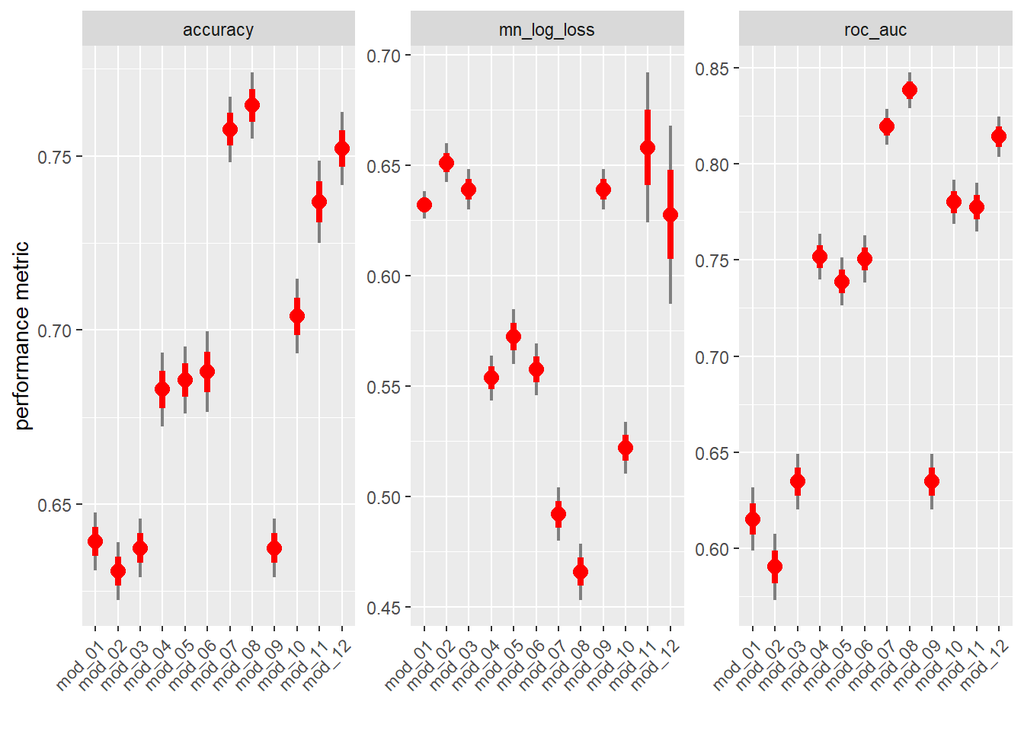

```r
glm_cv_summary %>%
  ggplot(mapping = aes(x = wflow_id)) +
  geom_linerange(mapping = aes(ymin = mean - 2*std_err,
                               ymax = mean + 2*std_err,
                               group = interaction(.metric, wflow_id)),
                 color = "grey50", size = 0.75) +
  geom_linerange(mapping = aes(ymin = mean - 1*std_err,
                               ymax = mean + 1*std_err,
                               group = interaction(.metric, wflow_id)),
                 color = "red", size = 1.45) +
  geom_point(mapping = aes(y = mean),
             color = "red", size = 3.1) +
  facet_wrap(~.metric, scales = "free_y", nrow = 1) +
  labs(x = "", y = "performance metric") +
  theme(axis.text.x = element_text(angle = 45, vjust = 1, hjust = 1))
```

From the above figure we ca tell that according to all metrics that is **accuracy**, **mn_log_loss**, and **roc_auc** model-8 is the best model.

```r
glm_cv_result <- glm_mod1 %>% collect_predictions(summarise = FALSE) %>%
  mutate(wflow_id = "mod_01") %>%
  bind_rows(glm_mod2 %>% collect_predictions(summarise = FALSE) %>%
              mutate(wflow_id = "mod_02")) %>%
  bind_rows(glm_mod3 %>% collect_predictions(summarise = FALSE) %>%
              mutate(wflow_id = "mod_03"))%>%
  bind_rows(glm_mod4 %>% collect_predictions(summarise = FALSE) %>%
              mutate(wflow_id = "mod_04"))%>%
  bind_rows(glm_mod5 %>% collect_predictions(summarise = FALSE) %>%
              mutate(wflow_id = "mod_05"))%>%
  bind_rows(glm_mod6 %>% collect_predictions(summarise = FALSE) %>%
              mutate(wflow_id = "mod_06"))%>%
  bind_rows(glm_mod7 %>% collect_predictions(summarise = FALSE) %>%
              mutate(wflow_id = "mod_07"))%>%
  bind_rows(glm_mod8 %>% collect_predictions(summarise = FALSE) %>%
              mutate(wflow_id = "mod_08"))%>%
  bind_rows(glm_mod9 %>% collect_predictions(summarise = FALSE) %>%
              mutate(wflow_id = "mod_09"))%>%
  bind_rows(glm_mod10 %>% collect_predictions(summarise = FALSE) %>%
              mutate(wflow_id = "mod_10"))%>%
  bind_rows(glm_mod11 %>% collect_predictions(summarise = FALSE) %>%
              mutate(wflow_id = "mod_11"))%>%
  bind_rows(glm_mod12 %>% collect_predictions(summarise = FALSE) %>%
              mutate(wflow_id = "mod_12"))
```

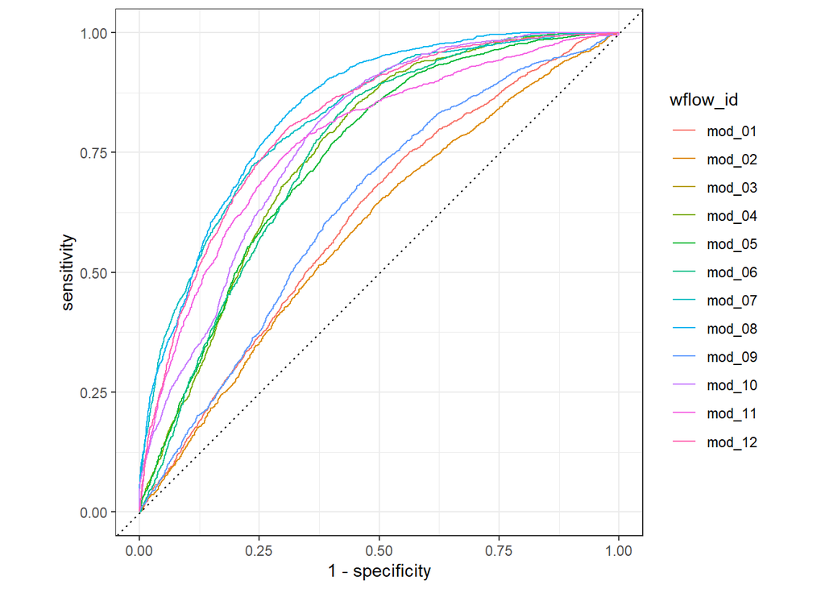

```r
glm_cv_result %>%
  group_by(wflow_id) %>%
  roc_curve(outcome, .pred_event) %>%
  autoplot()
```

**First fitting the top-3 models**

```r
final_glm_mod7 <- glm_mod7_wflow %>%
  fit(df_cat)
```

```r
final_glm_mod8 <- glm_mod8_wflow %>%
  fit(df_derived_cat)
```

```r
final_glm_mod12 <- glm_mod12_wflow %>%
  fit(df_derived_cat)
```

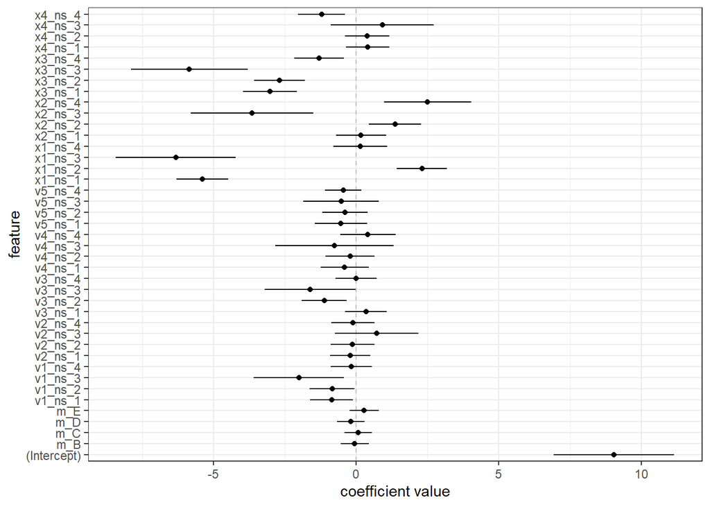

```r
tidy(final_glm_mod7) %>%
     ggplot(mapping = aes(x = term)) +
     geom_hline(yintercept = 0, color = "grey", linetype = "dashed") +
     geom_point(mapping = aes(y = estimate)) +
     geom_linerange(mapping = aes(ymin = estimate - 2*std.error,
                                  ymax = estimate + 2*std.error,
                                  group = term)) +
     labs(x = 'feature', y = 'coefficient value') +
     coord_flip() +
     theme_bw()
```

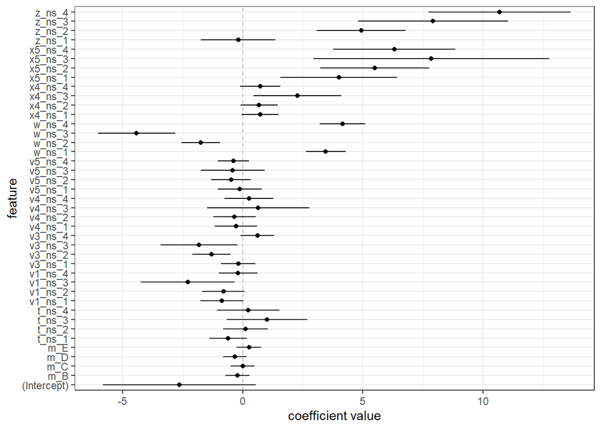

```r
tidy(final_glm_mod8) %>%
     ggplot(mapping = aes(x = term)) +
     geom_hline(yintercept = 0, color = "grey", linetype = "dashed") +
     geom_point(mapping = aes(y = estimate)) +
     geom_linerange(mapping = aes(ymin = estimate - 2*std.error,
                                  ymax = estimate + 2*std.error,
                                  group = term)) +
     labs(x = 'feature', y = 'coefficient value') +
     coord_flip() +
     theme_bw()
```

# NOn - Linear Models

##### Elastic Net

**Fitting a Lasso model to get idea about the intervals of the tuning parameter**

```r
lasso_for_fit <- logistic_reg(penalty = 0.1, mixture = 1) %>%
  set_engine("glmnet",
             intercept = TRUE, standardize = TRUE)
```

```r
bp_lasso <- bp_spline_base
```

```r
lasso_fit_wflow <- workflow() %>%
  add_model(lasso_for_fit) %>%
  add_recipe(bp_lasso)
```

```r
lasso_fit <- lasso_fit_wflow %>%
  fit(df_cat)
```

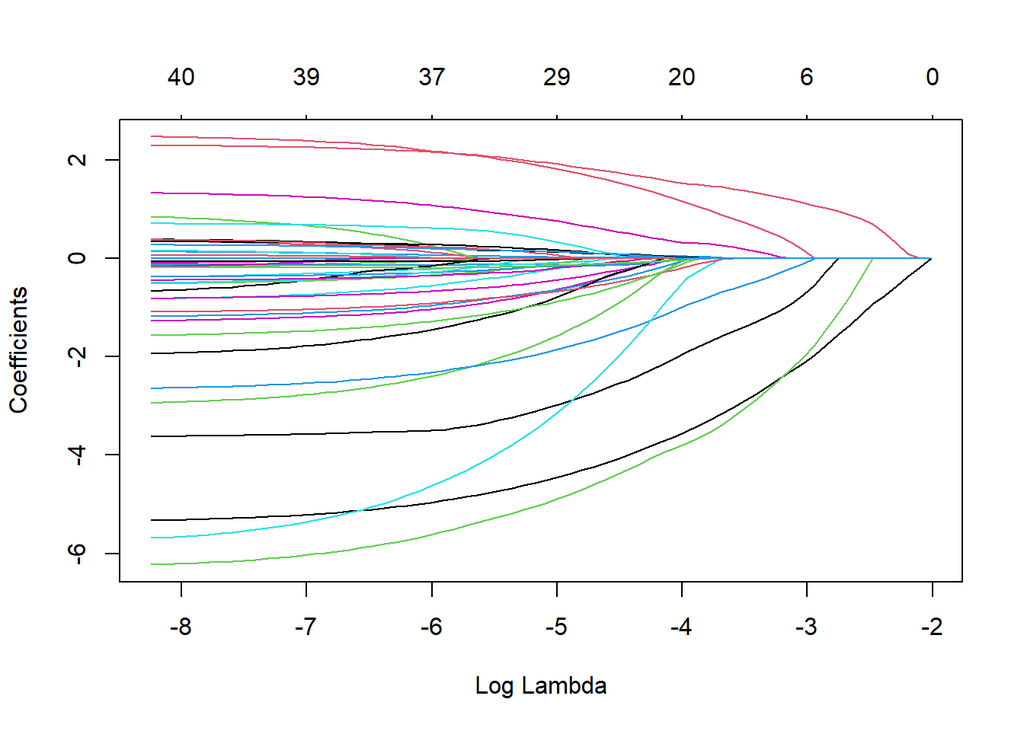

```r
lasso_fit %>% extract_fit_parsnip() %>%
  pluck("fit") %>%
  plot(xvar = "lambda")
```

```r
lasso_fit %>% extract_fit_parsnip() %>%
  pluck("fit") %>%
  broom:::tidy.glmnet() %>%
  distinct(lambda) %>%
  arrange(lambda) %>%
  pull() %>%
  log() %>%
  summary()
```

```
##    Min. 1st Qu.  Median    Mean 3rd Qu.    Max.
##  -8.244  -6.685  -5.127  -5.127  -3.569  -2.011
```

```r
my_lambda <- penalty(range = c(-10, -1), trans = log_trans())

my_alpha <- mixture(range = c(0.1, 1.0))

enet_grid <- grid_regular(my_lambda, my_alpha,
                          levels = c(penalty = 75, mixture = 5))
```

```r
enet_spec <- logistic_reg(penalty = tune(), mixture = tune()) %>%
  set_engine("glmnet",
             intercept = TRUE, standardize = TRUE,
             path_values = exp(seq(-10, -1, length.out = 75)))
```

```r
bp_enet <- recipe(outcome ~., data = df_cat) %>%
  step_BoxCox(x2) %>%
  step_center(all_numeric_predictors()) %>%
  step_scale(all_numeric_predictors()) %>%
  step_dummy(m) %>%
  step_interact( ~ all_numeric_predictors() : all_numeric_predictors())
```

```r
enet_wflow <- workflow() %>%
  add_model(enet_spec) %>%
  add_recipe(bp_enet)
```

```r
if(parallel::detectCores(logical=FALSE) > 3){
  library(doParallel)

  num_cores <- parallel::detectCores(logical=FALSE)
  cl <- makePSOCKcluster(num_cores - 1)
  registerDoParallel(cl)
}
start_enet <- Sys.time()

enet_res <- tune_grid(
  enet_wflow,
  resamples = cv_folds_1,
  grid = enet_grid,
  metrics = my_metrics
)

finish_enet <- Sys.time()

finish_enet - start_enet
```

```
## Time difference of 1.088889 mins
```

**We will visualize the results**

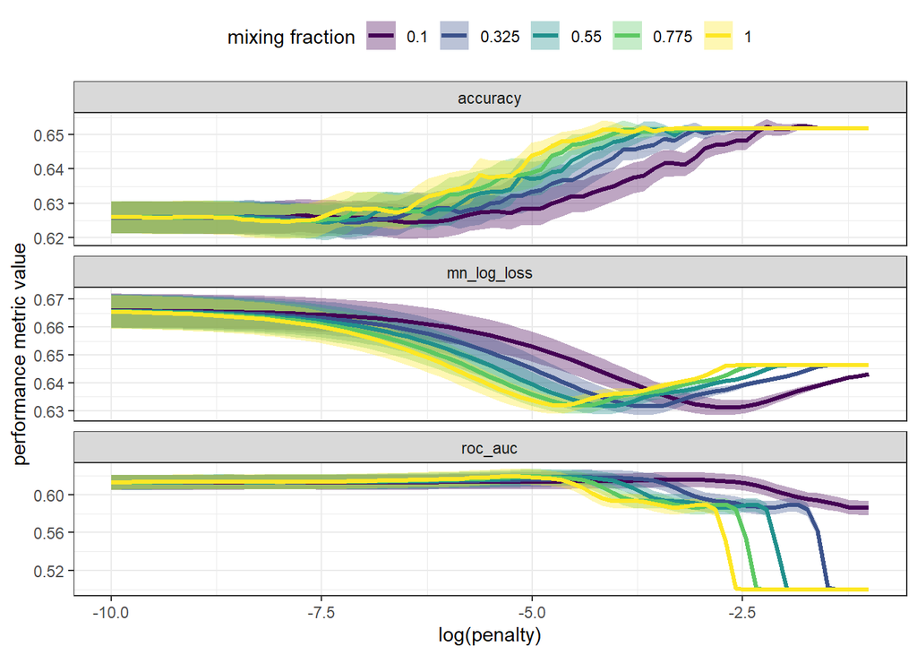

```r
enet_res %>% collect_metrics() %>%
  ggplot(mapping = aes(x = log(penalty))) +
  geom_ribbon(mapping = aes(ymin = mean - std_err,
                            ymax = mean + std_err,
                            group = interaction(mixture, .metric),
                            fill = as.factor(mixture)),
              alpha = 0.35) +
  geom_line(mapping = aes(y = mean,
                          group = interaction(mixture, .metric),
                          color = as.factor(mixture)),
            size = 1.15) +
  facet_wrap(~.metric, scales = "free_y", ncol = 1) +
  scale_fill_viridis_d("mixing fraction") +
  scale_color_viridis_d("mixing fraction") +
  labs(y = "performance metric value") +
  theme_bw() +
  theme(legend.position = "top")
```

Checking which tuning parameter is the best according to **roc_auc**

```r
enet_res %>% select_best(metric = "roc_auc")
```

```
## # A tibble: 1 × 3
##   penalty mixture .config
##     <dbl>   <dbl> <chr>
## 1 0.00521       1 Preprocessor1_Model340
```

Since the value of mixture is one our model is a Lasso model.

Tunining parameter based on 1-standard error rule.

```r
enet_res %>%
  select_by_one_std_err(desc(penalty), desc(mixture), metric = "roc_auc")
```

```
## # A tibble: 1 × 10
##   penalty mixture .metric .estimator  mean     n std_err .config    .best .bound
##     <dbl>   <dbl> <chr>   <chr>      <dbl> <int>   <dbl> <chr>      <dbl>  <dbl>
## 1  0.0855     0.1 roc_auc binary     0.612    50 0.00789 Preproces… 0.619  0.611
```

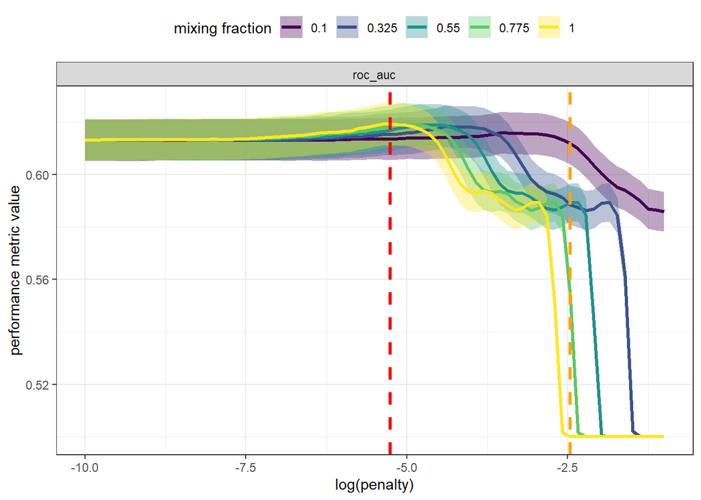

```r
enet_res %>% collect_metrics() %>%
  filter(.metric %in% c("roc_auc")) %>%
  ggplot(mapping = aes(x = log(penalty))) +
  geom_ribbon(mapping = aes(ymin = mean - std_err,
                            ymax = mean + std_err,
                            group = interaction(mixture, .metric),
                            fill = as.factor(mixture)),
              alpha = 0.35) +
  geom_line(mapping = aes(y = mean,
                          group = interaction(mixture, .metric),
                          color = as.factor(mixture)),
            size = 1.15) +
  geom_vline(data = enet_res %>% select_best("roc_auc"),
             mapping = aes(xintercept = log(penalty)),
             color = 'red', linetype = 'dashed', size = 1.2) +
  geom_vline(data = enet_res %>%
               select_by_one_std_err(desc(penalty), desc(mixture), metric = 'roc_auc'),
             mapping = aes(xintercept = log(penalty)),
             color = 'orange', linetype = 'dashed', size = 1.2) +
  facet_wrap(~.metric, scales = "free_y", ncol = 1) +
  scale_fill_viridis_d("mixing fraction") +
  scale_color_viridis_d("mixing fraction") +
  labs(y = 'performance metric value') +
  theme_bw() +
  theme(legend.position = "top")
```

```r
enet_best_roc_auc_params <- enet_res %>%
  select_by_one_std_err(desc(penalty), desc(mixture), metric = 'roc_auc') %>%
  select(all_of(names(enet_grid)))

final_enet_wflow <- enet_wflow %>%
  finalize_workflow(enet_best_roc_auc_params)
```

```r
final_enet_res <- final_enet_wflow %>%
  fit_resamples(cv_folds_1,
                metrics = my_metrics,
                control = control_resamples(save_pred = TRUE))
```

```r
final_enet_res %>% collect_metrics()
```

```
## # A tibble: 3 × 6
##   .metric     .estimator  mean     n std_err .config
##   <chr>       <chr>      <dbl> <int>   <dbl> <chr>
## 1 accuracy    binary     0.648    50 0.00261 Preprocessor1_Model1
## 2 mn_log_loss binary     0.632    50 0.00233 Preprocessor1_Model1
## 3 roc_auc     binary     0.612    50 0.00789 Preprocessor1_Model1
```

```r
final_enet_fit <- final_enet_wflow %>% fit(df_cat)
```

```r
final_enet_fit %>%
  tidy() %>%
  filter(!stringr::str_detect(term, "Intercept")) %>%
  summarise(num_zero = sum(estimate == 0),
            fraction_zero = mean(estimate == 0))
```

```
## # A tibble: 1 × 2
##   num_zero fraction_zero
##      <int>         <dbl>
## 1       46         0.505
```

**Elastic net using the mode-7**

```r
enet_wflow_glm7 <- workflow() %>%
  add_model(enet_spec) %>%
  add_recipe(bp_spline_base)
```

```r
start_enet <- Sys.time()

enet_glm7_res <- tune_grid(
  enet_wflow_glm7,
  resamples = cv_folds_1,
  grid = enet_grid,
  metrics = my_metrics
)

finish_enet <- Sys.time()

finish_enet - start_enet
```

```
## Time difference of 46.70146 secs
```

**We will visualize the results**

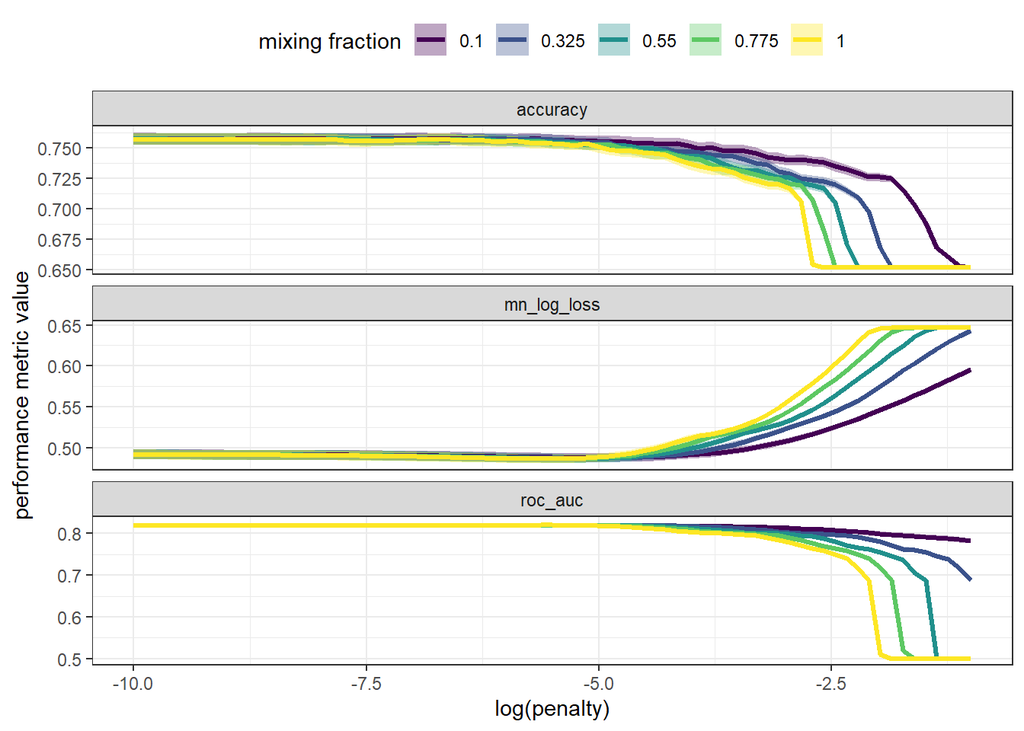

```r
enet_glm7_res %>% collect_metrics() %>%
  ggplot(mapping = aes(x = log(penalty))) +
  geom_ribbon(mapping = aes(ymin = mean - std_err,
                            ymax = mean + std_err,
                            group = interaction(mixture, .metric),
                            fill = as.factor(mixture)),
              alpha = 0.35) +
  geom_line(mapping = aes(y = mean,
                          group = interaction(mixture, .metric),
                          color = as.factor(mixture)),
            size = 1.15) +
  facet_wrap(~.metric, scales = "free_y", ncol = 1) +
  scale_fill_viridis_d("mixing fraction") +
  scale_color_viridis_d("mixing fraction") +
  labs(y = "performance metric value") +
  theme_bw() +
  theme(legend.position = "top")
```

Checking which tuning parameter is the best according to **roc_auc**

```r
enet_glm7_res %>% select_best(metric = "roc_auc")
```

```
## # A tibble: 1 × 3
##   penalty mixture .config
##     <dbl>   <dbl> <chr>
## 1 0.00409       1 Preprocessor1_Model338
```

Since the value of mixture is one our model is a Lasso model.

Tuning parameter based on 1-standard error rule.

```r
enet_glm7_res %>%
  select_by_one_std_err(desc(penalty), desc(mixture), metric = "roc_auc")
```

```
## # A tibble: 1 × 10
##   penalty mixture .metric .estimator  mean     n std_err .config    .best .bound
##     <dbl>   <dbl> <chr>   <chr>      <dbl> <int>   <dbl> <chr>      <dbl>  <dbl>
## 1  0.0365     0.1 roc_auc binary     0.816    50 0.00523 Preproces… 0.820  0.815
```

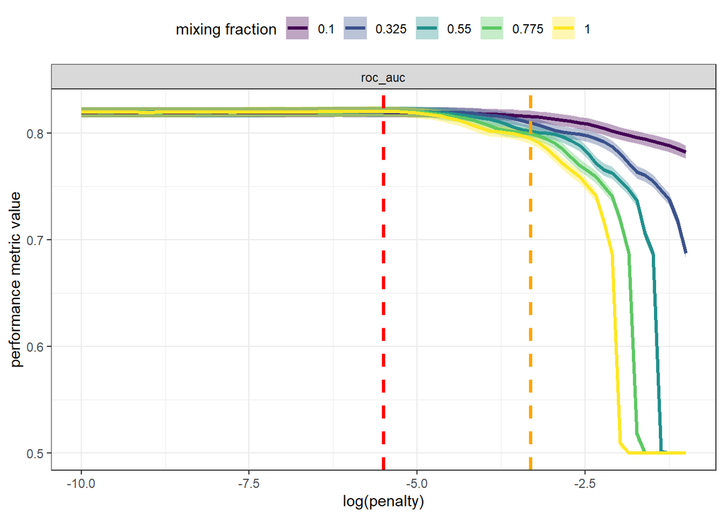

```r
enet_glm7_res %>% collect_metrics() %>%
  filter(.metric %in% c("roc_auc")) %>%
  ggplot(mapping = aes(x = log(penalty))) +
  geom_ribbon(mapping = aes(ymin = mean - std_err,
                            ymax = mean + std_err,
                            group = interaction(mixture, .metric),
                            fill = as.factor(mixture)),
              alpha = 0.35) +
  geom_line(mapping = aes(y = mean,
                          group = interaction(mixture, .metric),
                          color = as.factor(mixture)),
            size = 1.15) +
  geom_vline(data = enet_glm7_res %>% select_best("roc_auc"),
             mapping = aes(xintercept = log(penalty)),
             color = 'red', linetype = 'dashed', size = 1.2) +
  geom_vline(data = enet_glm7_res %>%
               select_by_one_std_err(desc(penalty), desc(mixture), metric = 'roc_auc'),
             mapping = aes(xintercept = log(penalty)),
             color = 'orange', linetype = 'dashed', size = 1.2) +
  facet_wrap(~.metric, scales = "free_y", ncol = 1) +
  scale_fill_viridis_d("mixing fraction") +
  scale_color_viridis_d("mixing fraction") +
  labs(y = 'performance metric value') +
  theme_bw() +
  theme(legend.position = "top")
```

```r
enet_glm7_best_roc_auc_params <- enet_glm7_res %>%
  select_by_one_std_err(desc(penalty), desc(mixture), metric = "roc_auc") %>%
  select(all_of(names(enet_grid)))

final_enet_glm7_wflow <- enet_wflow_glm7 %>%
  finalize_workflow(enet_glm7_best_roc_auc_params)
```

```r
final_glm7_enet_res <- final_enet_glm7_wflow %>%
  fit_resamples(cv_folds_1,
                metrics = my_metrics,
                control = control_resamples(save_pred = TRUE))
```

```r
final_glm7_enet_res %>% collect_metrics()
```

```
## # A tibble: 3 × 6
##   .metric     .estimator  mean     n std_err .config
##   <chr>       <chr>      <dbl> <int>   <dbl> <chr>
## 1 accuracy    binary     0.746    50 0.00504 Preprocessor1_Model1
## 2 mn_log_loss binary     0.501    50 0.00402 Preprocessor1_Model1
## 3 roc_auc     binary     0.816    50 0.00523 Preprocessor1_Model1
```

```r
final_glm7_enet_fit <- final_enet_glm7_wflow %>% fit(df_cat)
```

```r
final_glm7_enet_fit %>%
  tidy() %>%
  filter(!stringr::str_detect(term, "Intercept")) %>%
  summarise(num_zero = sum(estimate == 0),
            fraction_zero = mean(estimate == 0))
```

```
## # A tibble: 1 × 2
##   num_zero fraction_zero
##      <int>         <dbl>
## 1        9         0.225
```

**Elastic net using the mode-8**

```r
enet_wflow_glm8 <- workflow() %>%
  add_model(enet_spec) %>%
  add_recipe(bp_spline_exp)
```

```r
start_enet <- Sys.time()

enet_glm8_res <- tune_grid(
  enet_wflow_glm8,
  resamples = cv_folds_2,
  grid = enet_grid,
  metrics = my_metrics
)

finish_enet <- Sys.time()

finish_enet - start_enet
```

```
## Time difference of 48.33158 secs
```

**We will visualize the results**

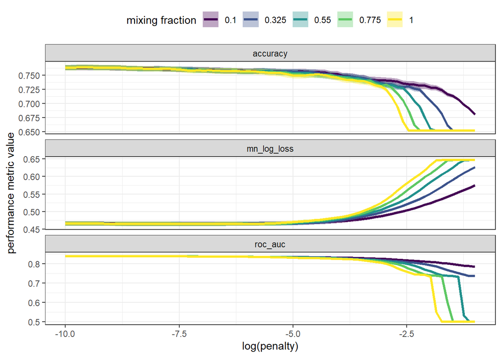

```r
enet_glm8_res %>% collect_metrics() %>%
  ggplot(mapping = aes(x = log(penalty))) +
  geom_ribbon(mapping = aes(ymin = mean - std_err,
                            ymax = mean + std_err,
                            group = interaction(mixture, .metric),
                            fill = as.factor(mixture)),
              alpha = 0.35) +
  geom_line(mapping = aes(y = mean,
                          group = interaction(mixture, .metric),
                          color = as.factor(mixture)),
            size = 1.15) +
  facet_wrap(~.metric, scales = "free_y", ncol = 1) +
  scale_fill_viridis_d("mixing fraction") +
  scale_color_viridis_d("mixing fraction") +
  labs(y = "performance metric value") +
  theme_bw() +
  theme(legend.position = "top")
```

Checking which tuning parameter is the best according to **roc_auc**

```r
enet_glm8_res %>% select_best(metric = "roc_auc")
```

```
## # A tibble: 1 × 3
##    penalty mixture .config
##      <dbl>   <dbl> <chr>
## 1 0.000120   0.775 Preprocessor1_Model234
```

Tuning parameter based on 1-standard error rule.

```r
enet_glm8_res %>%
  select_by_one_std_err(desc(penalty), desc(mixture), metric = "roc_auc")
```

```
## # A tibble: 1 × 10
##   penalty mixture .metric .estimator  mean     n std_err .config    .best .bound
##     <dbl>   <dbl> <chr>   <chr>      <dbl> <int>   <dbl> <chr>      <dbl>  <dbl>
## 1 0.00957   0.325 roc_auc binary     0.834    50 0.00493 Preproces… 0.838  0.834
```

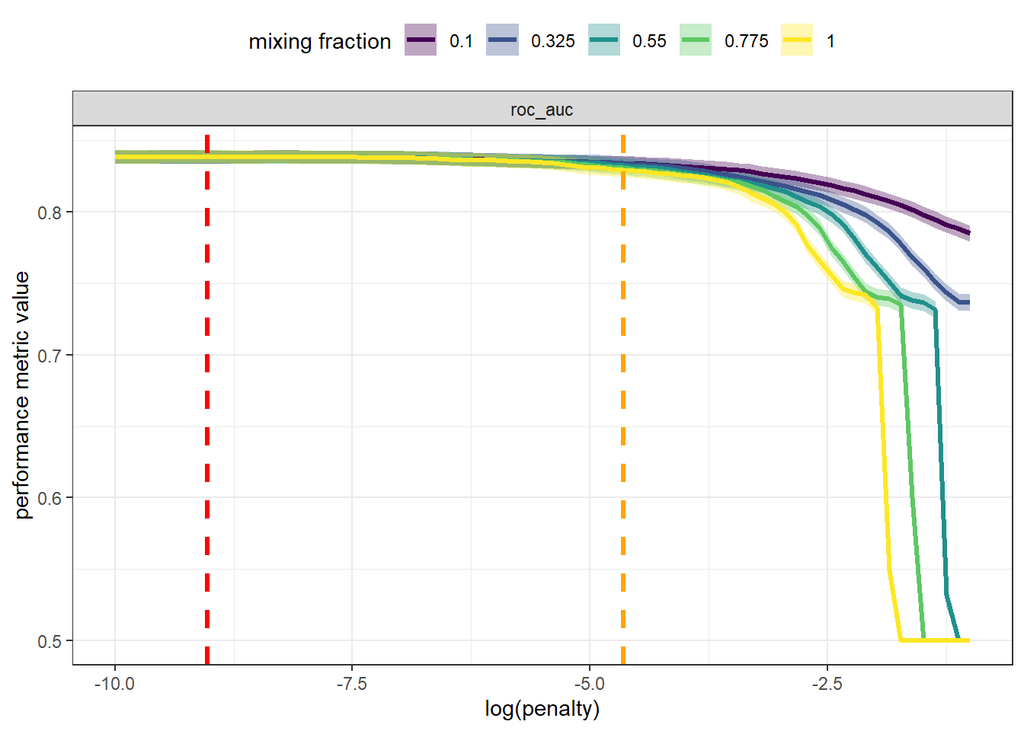

```r
enet_glm8_res %>% collect_metrics() %>%
  filter(.metric %in% c("roc_auc")) %>%
  ggplot(mapping = aes(x = log(penalty))) +
  geom_ribbon(mapping = aes(ymin = mean - std_err,
                            ymax = mean + std_err,
                            group = interaction(mixture, .metric),
                            fill = as.factor(mixture)),
              alpha = 0.35) +
  geom_line(mapping = aes(y = mean,
                          group = interaction(mixture, .metric),
                          color = as.factor(mixture)),
            size = 1.15) +
  geom_vline(data = enet_glm8_res %>% select_best("roc_auc"),
             mapping = aes(xintercept = log(penalty)),
             color = 'red', linetype = 'dashed', size = 1.2) +
  geom_vline(data = enet_glm8_res %>%
               select_by_one_std_err(desc(penalty), desc(mixture), metric = 'roc_auc'),
             mapping = aes(xintercept = log(penalty)),
             color = 'orange', linetype = 'dashed', size = 1.2) +
  facet_wrap(~.metric, scales = "free_y", ncol = 1) +
  scale_fill_viridis_d("mixing fraction") +
  scale_color_viridis_d("mixing fraction") +
  labs(y = 'performance metric value') +
  theme_bw() +
  theme(legend.position = "top")
```

```r
enet_glm8_best_roc_auc_params <- enet_glm8_res %>%
  select_by_one_std_err(desc(penalty), desc(mixture), metric = "roc_auc") %>%
  select(all_of(names(enet_grid)))

final_enet_glm8_wflow <- enet_wflow_glm8 %>%
  finalize_workflow(enet_glm8_best_roc_auc_params)
```

```r
final_glm8_enet_res <- final_enet_glm8_wflow %>%
  fit_resamples(cv_folds_2,
                metrics = my_metrics,
                control = control_resamples(save_pred = TRUE))
```

```r
final_glm8_enet_res %>% collect_metrics()
```

```
## # A tibble: 3 × 6
##   .metric     .estimator  mean     n std_err .config
##   <chr>       <chr>      <dbl> <int>   <dbl> <chr>
## 1 accuracy    binary     0.755    50 0.00539 Preprocessor1_Model1
## 2 mn_log_loss binary     0.468    50 0.00515 Preprocessor1_Model1
## 3 roc_auc     binary     0.834    50 0.00493 Preprocessor1_Model1
```

```r
final_glm8_enet_fit <- final_enet_glm8_wflow %>% fit(df_derived_cat)
```

```r
final_glm8_enet_fit %>%
  tidy() %>%
  filter(!stringr::str_detect(term, "Intercept")) %>%
  summarise(num_zero = sum(estimate == 0),
            fraction_zero = mean(estimate == 0))
```

```
## # A tibble: 1 × 2
##   num_zero fraction_zero
##      <int>         <dbl>
## 1       10          0.25
```

```r
all_results <- glm_mod1 %>% collect_metrics() %>%
  mutate(wflow_id = "mod_01") %>%
  bind_rows(glm_mod4 %>% collect_metrics() %>%
              mutate(wflow_id = "mod_04")) %>%
  bind_rows(glm_mod7 %>% collect_metrics() %>%
              mutate(wflow_id = "mod_07")) %>%
  bind_rows(glm_mod8 %>% collect_metrics() %>%
              mutate(wflow_id = "mod_08")) %>%
  bind_rows(final_enet_res %>% collect_metrics() %>%
              mutate(wflow_id = "enet")) %>%
  bind_rows(final_glm7_enet_res %>% collect_metrics() %>%
              mutate(wflow_id = "enet_7")) %>%
  bind_rows(final_glm8_enet_res %>% collect_metrics() %>%
              mutate(wflow_id = "enet_8"))
```

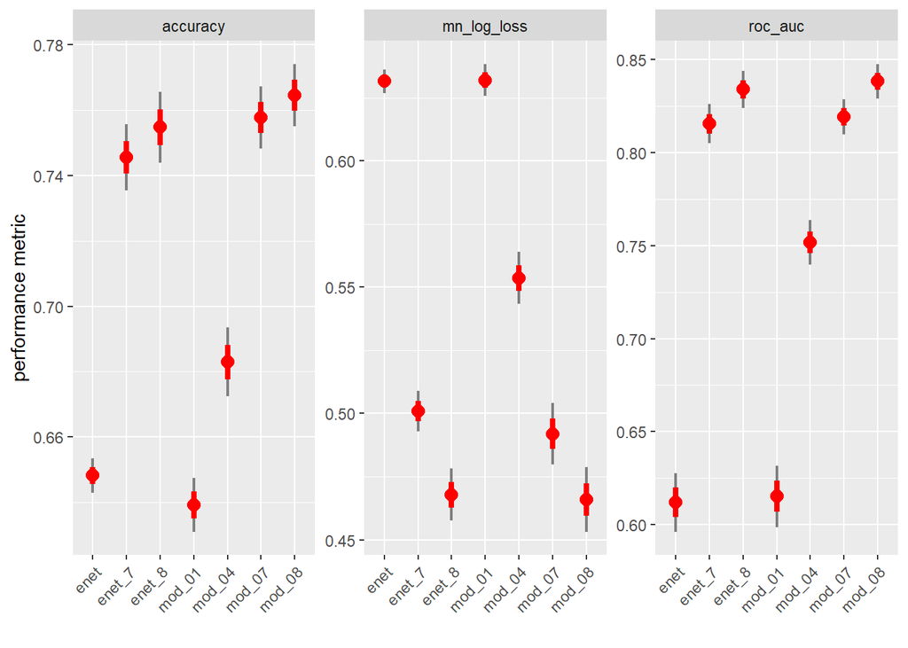

```r
all_results %>%
  ggplot(mapping = aes(x = wflow_id)) +
  geom_linerange(mapping = aes(ymin = mean - 2*std_err,
                               ymax = mean + 2*std_err,
                               group = interaction(.metric, wflow_id)),
                 color = "grey50", size = 0.75) +
  geom_linerange(mapping = aes(ymin = mean - 1*std_err,
                               ymax = mean + 1*std_err,
                               group = interaction(.metric, wflow_id)),
                 color = "red", size = 1.45) +
  geom_point(mapping = aes(y = mean),
             color = "red", size = 3.1) +
  facet_wrap(~.metric, scales = "free_y", nrow = 1) +
  labs(x = "", y = "performance metric") +
  theme(axis.text.x = element_text(angle = 45, vjust = 1, hjust = 1))
```

##### Neural Network

**Using Base Features**

```r
nnet_spec <- mlp(hidden_units = tune(), penalty = tune(), epochs = 2000) %>%
  set_engine("nnet", MaxNWts = 2000, trace=FALSE) %>%
  set_mode("classification")
```

```r
nnet_grid <- crossing(hidden_units = c(5, 10, 15, 25, 30),
                      penalty = 10^(seq(-10, 1.75, length.out = 21)))
```

```r
nnet_base_wflow <- workflow() %>%
  add_model(nnet_spec) %>%
  add_recipe(bp_stan_base)
```

```r
start_nnet <- Sys.time()

set.seed(111)
nnet_base_res <- tune_grid(
  nnet_base_wflow,
  resamples = cv_folds_1,
  grid = nnet_grid,
  metrics = my_metrics
)

finish_nnet <- Sys.time()

finish_nnet - start_nnet
```

```r
nnet_base_res %>% readr::write_rds("nnet_classi_base_model.rds")
```

```r
nnet_base_res <- readr::read_rds("nnet_classi_base_model.rds")
```

**Visualizing the result**

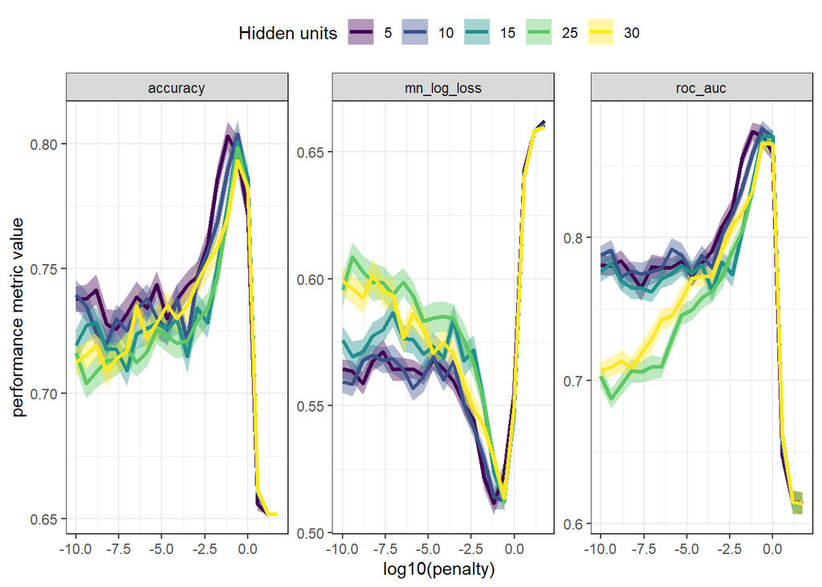

```r
nnet_base_res %>% collect_metrics() %>%
  ggplot(mapping = aes(x = log10(penalty))) +
  geom_ribbon(mapping = aes(group = interaction(hidden_units, .metric),
                            fill = as.factor(hidden_units),
                            ymin = mean - std_err,
                            ymax = mean + std_err),
              alpha = 0.4) +
  geom_line(mapping = aes(group = interaction(hidden_units, .metric),
                          color = as.factor(hidden_units),
                          y = mean),
            size = 1.2) +
  facet_wrap(~.metric, scales = "free_y", nrow = 1) +
  scale_fill_viridis_d("Hidden units") +
  scale_color_viridis_d("Hidden units") +
  labs(y = 'performance metric value') +
  theme_bw() +
  theme(legend.position = "top")
```

**Selecting Tuning Parameters that maximize roc_auc**

```r
nnet_base_best_max_acc_params <- nnet_base_res %>%
  select_best(metric = 'roc_auc')
```

```r
final_nnet_base_wflow <- nnet_base_wflow %>%
  finalize_workflow(nnet_base_best_max_acc_params)
```

**Final neural network workflow**

```r
final_nnet_base_res <- final_nnet_base_wflow %>%
  fit_resamples(cv_folds_1,
                metrics = my_metrics,
                control = control_resamples(save_pred = TRUE))
```

```r
all_results <- all_results %>%
  bind_rows(final_nnet_base_res %>% collect_metrics() %>%
              mutate(wflow_id = "nnet_base"))
```

**Using Expanded Features**

```r
nnet_exp_wflow <- workflow() %>%
  add_model(nnet_spec) %>%
  add_recipe(bp_stan_exp)
```

```r
start_nnet <- Sys.time()

set.seed(111)
nnet_exp_res <- tune_grid(
  nnet_base_wflow,
  resamples = cv_folds_2,
  grid = nnet_grid,
  metrics = my_metrics
)

finish_nnet <- Sys.time()

finish_nnet - start_nnet
```

```r
nnet_exp_res %>% readr::write_rds("nnet_classi_exp_model.rds")
```

```r
nnet_exp_res <- readr::read_rds("nnet_classi_exp_model.rds")
```

**Visualizing the result**

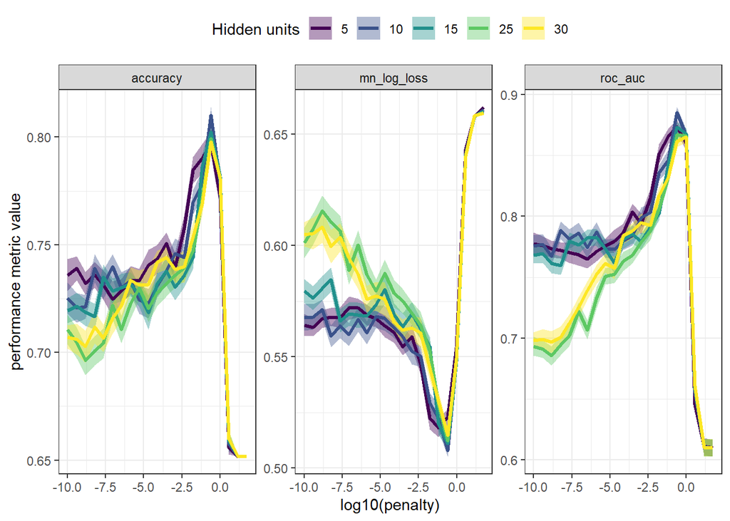

```r
nnet_exp_res %>% collect_metrics() %>%
  ggplot(mapping = aes(x = log10(penalty))) +
  geom_ribbon(mapping = aes(group = interaction(hidden_units, .metric),
                            fill = as.factor(hidden_units),
                            ymin = mean - std_err,
                            ymax = mean + std_err),
              alpha = 0.4) +
  geom_line(mapping = aes(group = interaction(hidden_units, .metric),
                          color = as.factor(hidden_units),
                          y = mean),
            size = 1.2) +
  facet_wrap(~.metric, scales = "free_y", nrow = 1) +
  scale_fill_viridis_d("Hidden units") +
  scale_color_viridis_d("Hidden units") +
  labs(y = 'performance metric value') +
  theme_bw() +
  theme(legend.position = "top")
```

**Selecting Tuning Parameters that maximize roc_auc**

```r
nnet_exp_best_max_acc_params <- nnet_exp_res %>%
  select_best(metric = 'roc_auc')
```

```r
final_nnet_exp_wflow <- nnet_exp_wflow %>%
  finalize_workflow(nnet_exp_best_max_acc_params)
```

**Final neural network workflow**

```r
final_nnet_exp_res <- final_nnet_exp_wflow %>%
  fit_resamples(cv_folds_2,
                metrics = my_metrics,
                control = control_resamples(save_pred = TRUE))
```

```r
all_results <- all_results %>%
  bind_rows(final_nnet_exp_res %>% collect_metrics() %>%
              mutate(wflow_id = "nnet_exp"))
```

### Random Forest

**Using Base Features**

```r
rf_spec <- rand_forest(mtry = tune(), min_n = tune(), trees = 500) %>%
  set_engine("ranger") %>%
  set_mode('classification')
```

```r
rf_base_wflow <- workflow() %>%
  add_model(rf_spec) %>%
  add_formula(outcome ~ .)
```

```r
rf_param_base <- rf_spec %>% parameters() %>% finalize(df_cat)
rf_grid_base <- grid_regular(rf_param_base, levels = c(mtry = 7, min_n = 15),
                        filter = min_n < 11)

rf_grid_base %>% glimpse()
```

```
## Rows: 28
## Columns: 2
## $ mtry  <int> 1, 2, 4, 6, 7, 9, 11, 1, 2, 4, 6, 7, 9, 11, 1, 2, 4, 6, 7, 9, 11…
## $ min_n <int> 2, 2, 2, 2, 2, 2, 2, 4, 4, 4, 4, 4, 4, 4, 7, 7, 7, 7, 7, 7, 7, 1…
```

```r
start_rf <- Sys.time()

set.seed(7899)
rf_base_res <- tune_grid(
  rf_base_wflow,
  resamples = cv_folds_1,
  grid = rf_grid_base,
  metrics = my_metrics
)

finish_rf <- Sys.time()

finish_rf - start_rf
```

```r
rf_base_res %>% readr::write_rds("rf_classi_base_model.rds")
```

```r
rf_base_res <- readr::read_rds("rf_classi_base_model.rds")
```

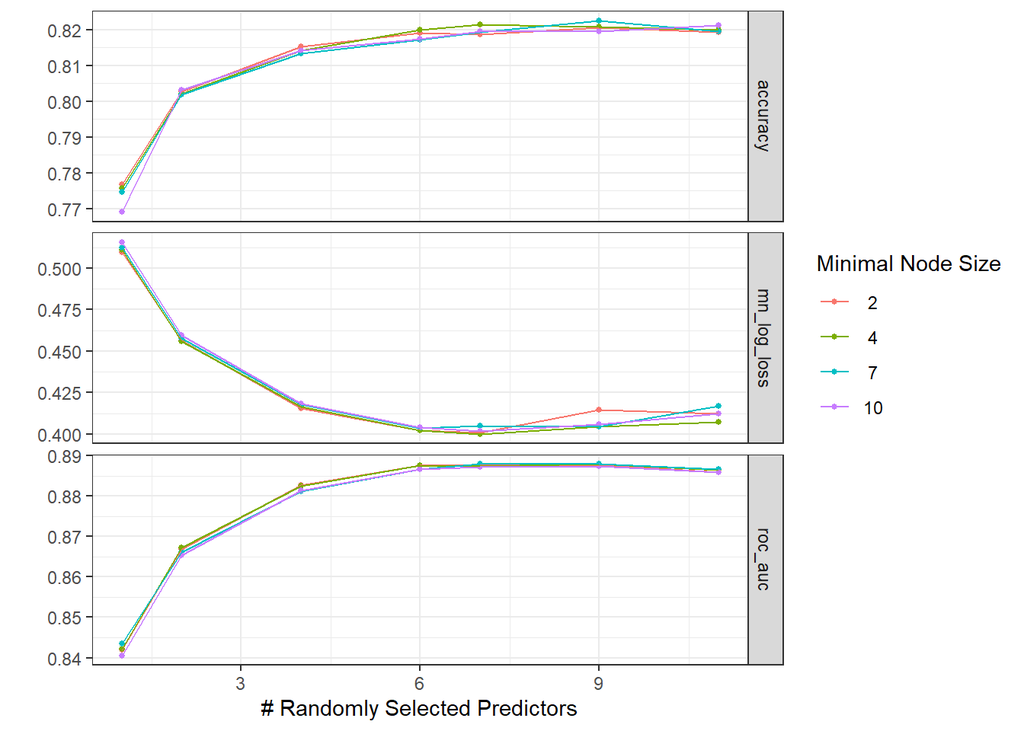

```r
rf_base_res %>% autoplot() + theme_bw()
```

```r
rf_base_best_acc_params <- rf_base_res %>% select_best('accuracy')
```

```r
final_rf_base_spec <- rand_forest(mtry = 9,
                              min_n = 7,
                              trees = 500) %>%
  set_engine('ranger', importance = 'impurity') %>%
  set_mode('classification')

final_rf_wflow_base <- workflow() %>%
  add_model(final_rf_base_spec) %>%
  add_formula(outcome ~ .)
```

**Training and Accessing final model**

```r
final_rf_base_res <- final_rf_wflow_base %>%
  fit_resamples(cv_folds_1,
                metrics = my_metrics,
                control = control_resamples(save_pred = TRUE))
```

```r
set.seed(7899)
final_rf_base_fit <- final_rf_wflow_base %>%
  fit(df_cat)
```

```r
all_results <- all_results %>%
  bind_rows(final_rf_base_res %>% collect_metrics() %>%
              mutate(wflow_id = "rf_base"))
```

**Using Expanded Features**

```r
rf_exp_wflow <- workflow() %>%
  add_model(rf_spec) %>%
  add_formula(outcome ~ x4 + x5 + v1 + v3 + v4 + v5 + w + z + t + m)
```

```r
rf_param_exp <- rf_spec %>% parameters() %>% finalize(df_derived_cat)
rf_grid_exp <- grid_regular(rf_param_exp, levels = c(mtry = 7, min_n = 15),
                        filter = min_n < 11)

rf_grid_exp %>% glimpse()
```

```
## Rows: 28
## Columns: 2
## $ mtry  <int> 1, 3, 5, 8, 10, 12, 15, 1, 3, 5, 8, 10, 12, 15, 1, 3, 5, 8, 10, …
## $ min_n <int> 2, 2, 2, 2, 2, 2, 2, 4, 4, 4, 4, 4, 4, 4, 7, 7, 7, 7, 7, 7, 7, 1…
```

```r
start_rf <- Sys.time()

set.seed(7899)
rf_exp_res <- tune_grid(
  rf_exp_wflow,
  resamples = cv_folds_2,
  grid = rf_grid_exp,
  metrics = my_metrics
)

finish_rf <- Sys.time()

finish_rf - start_rf
```

```r
rf_exp_res %>% readr::write_rds("rf_classi_expanded_model.rds")
```

```r
rf_exp_res <- readr::read_rds("rf_classi_expanded_model.rds")
```

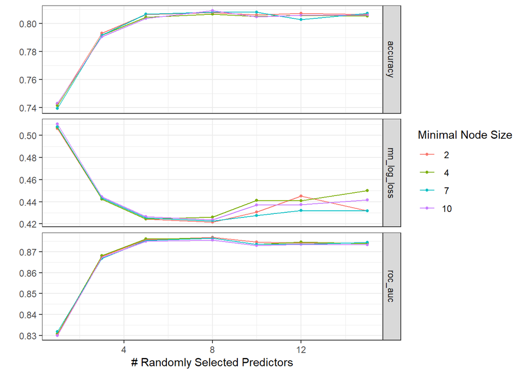

```r
rf_exp_res %>% autoplot() + theme_bw()
```

```r
rf_exp_best_acc_params <- rf_exp_res %>% select_best('accuracy')
```

```r
final_rf_exp_spec <- rand_forest(mtry = 8,
                              min_n = 10,
                              trees = 500) %>%
  set_engine('ranger', importance = 'impurity') %>%
  set_mode('classification')

final_rf_wflow_exp <- workflow() %>%
  add_model(final_rf_exp_spec) %>%
  add_formula(outcome ~ .)
```

**Training and Accessing final model**

```r
final_rf_exp_res <- final_rf_wflow_exp %>%
  fit_resamples(cv_folds_2,
                metrics = my_metrics,
                control = control_resamples(save_pred = TRUE))
```

```r
set.seed(7899)
final_rf_exp_fit <- final_rf_wflow_exp %>%
  fit(df_derived_cat)
```

```r
all_results <- all_results %>%
  bind_rows(final_rf_exp_res %>% collect_metrics() %>%
              mutate(wflow_id = "rf_exp"))
```

### Gradient Boosted Trees

**Using Base Features Set**

```r
xgb_spec <- boost_tree(tree_depth = tune(), learn_rate = tune(),
                       trees = tune(), mtry = tune(), sample_size = tune()) %>%
  set_engine("xgboost") %>%
  set_mode("classification")
```

```r
xgb_grid <- crossing(tree_depth = c(1, 3, 6, 9, 12),
                     learn_rate = c(0.01, 0.1, 0.3),
                     trees = c(25, 50, 100, 150, 200, 250, 300),
                     mtry = c(3, 6, 12, 24),
                     sample_size = c(0.6, 0.8, 1.0))

xgb_grid %>% glimpse()
```

```
## Rows: 1,260
## Columns: 5
## $ tree_depth  <dbl> 1, 1, 1, 1, 1, 1, 1, 1, 1, 1, 1, 1, 1, 1, 1, 1, 1, 1, 1, 1…
## $ learn_rate  <dbl> 0.01, 0.01, 0.01, 0.01, 0.01, 0.01, 0.01, 0.01, 0.01, 0.01…
## $ trees       <dbl> 25, 25, 25, 25, 25, 25, 25, 25, 25, 25, 25, 25, 50, 50, 50…
## $ mtry        <dbl> 3, 3, 3, 6, 6, 6, 12, 12, 12, 24, 24, 24, 3, 3, 3, 6, 6, 6…
## $ sample_size <dbl> 0.6, 0.8, 1.0, 0.6, 0.8, 1.0, 0.6, 0.8, 1.0, 0.6, 0.8, 1.0…
```

```r
xgb_wflow_base <- workflow() %>%
  add_model(xgb_spec) %>%
  add_formula(outcome ~ .)
```

```r
start_xgb <- Sys.time()

set.seed(111)
xgb_res_base <- tune_grid(
  xgb_wflow_base,
  resamples = cv_folds_1,
  grid = xgb_grid,
  metrics = my_metrics
)

finish_xgb <- Sys.time()

finish_xgb - start_xgb
```

```r
xgb_res_base %>% readr::write_rds("xgb_classi_base_model.rds")
```

```r
xgb_res_base <- readr::read_rds("xgb_classi_base_model.rds")
```

**The resampling results visualized for Accuracy.**

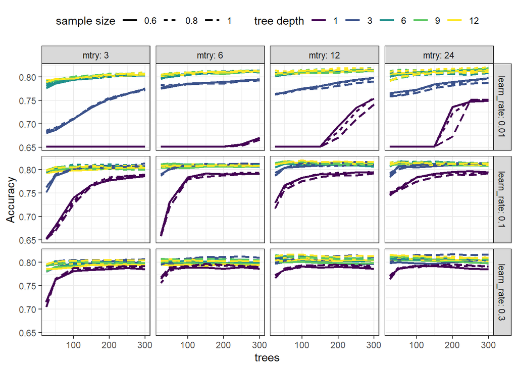

```r
xgb_res_base %>% collect_metrics() %>%
  filter(.metric == 'accuracy') %>%
  ggplot(mapping = aes(x = trees, y = mean)) +
  geom_line(mapping = aes(color = as.factor(tree_depth),
                          group = interaction(mtry, tree_depth,
                                              learn_rate, sample_size),
                          linetype = as.factor(sample_size)),
            size = 1.) +
  facet_grid(learn_rate ~ mtry, labeller = "label_both") +
  scale_color_viridis_d("tree depth") +
  scale_linetype_discrete("sample size") +
  labs(y = 'Accuracy') +
  theme_bw() +
  theme(legend.position = "top")
```

**The roc_auc resampling results**

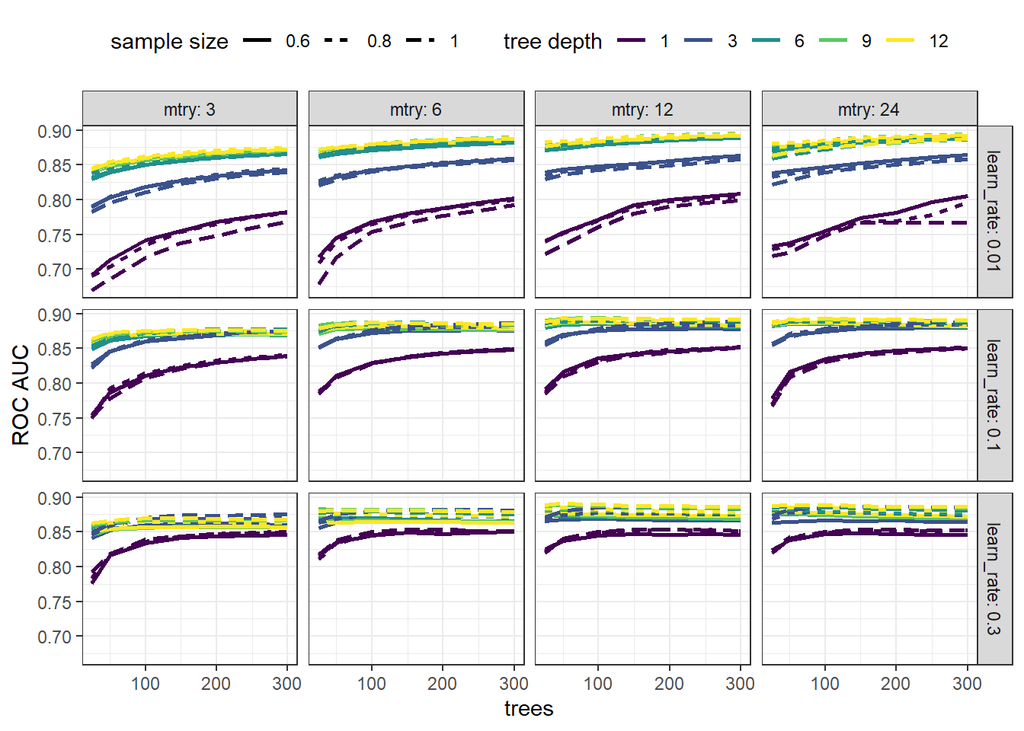

```r
xgb_res_base %>% collect_metrics() %>%
  filter(.metric == 'roc_auc') %>%
  ggplot(mapping = aes(x = trees, y = mean)) +
  geom_line(mapping = aes(color = as.factor(tree_depth),
                          group = interaction(mtry, tree_depth,
                                              learn_rate, sample_size),
                          linetype = as.factor(sample_size)),
            size = 1.) +
  facet_grid(learn_rate ~ mtry, labeller = "label_both") +
  scale_color_viridis_d("tree depth") +
  scale_linetype_discrete("sample size") +
  labs(y = 'ROC AUC') +
  theme_bw() +
  theme(legend.position = "top")
```

**The mean log loss resampling results**

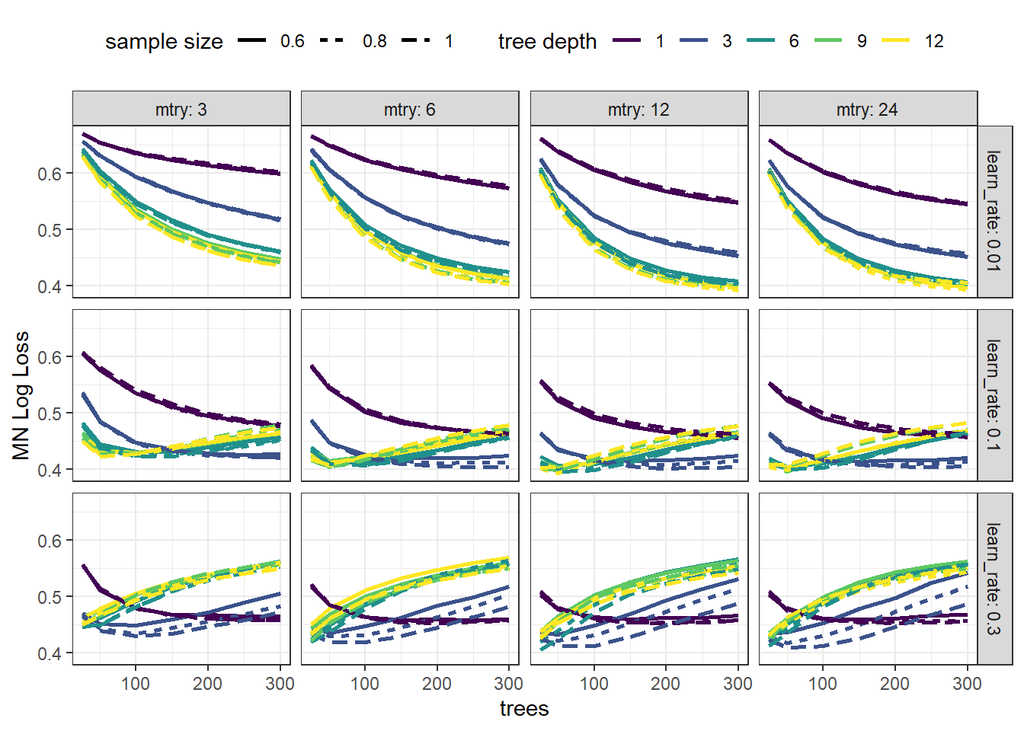

```r
xgb_res_base %>% collect_metrics() %>%
  filter(.metric == 'mn_log_loss') %>%
  ggplot(mapping = aes(x = trees, y = mean)) +
  geom_line(mapping = aes(color = as.factor(tree_depth),
                          group = interaction(mtry, tree_depth,
                                              learn_rate, sample_size),
                          linetype = as.factor(sample_size)),
            size = 1.) +
  facet_grid(learn_rate ~ mtry, labeller = "label_both") +
  scale_color_viridis_d("tree depth") +
  scale_linetype_discrete("sample size") +
  labs(y = 'MN Log Loss') +
  theme_bw() +
  theme(legend.position = "top")
```

```r
xgb_best_roc_params_base <- xgb_res_base %>% select_best('roc_auc')

final_xgb_wflow_base <- xgb_wflow_base %>%
  finalize_workflow(xgb_best_roc_params_base)
```

```r
set.seed(7899)
final_xgb_res_base <- final_xgb_wflow_base %>%
  fit_resamples(cv_folds_1,
                metrics = my_metrics,
                control = control_resamples(save_pred = TRUE))
```

```r
set.seed(7899)
final_xgb_fit_base <- final_xgb_wflow_base %>% fit(df_cat)
```

```r
all_results <- all_results %>%
  bind_rows(final_xgb_res_base %>% collect_metrics() %>%
              mutate(wflow_id = "xgb_base"))
```

**Using Expanded Features set**

```r
xgb_wflow_exp <- workflow() %>%
  add_model(xgb_spec) %>%
  add_formula(outcome ~ x4 + x5 + v1 + v3 + v4 + v5 + w + z + t + m)
```

```r
start_xgb <- Sys.time()

set.seed(7899)
xgb_res_exp <- tune_grid(
  xgb_wflow_exp,
  resamples = cv_folds_2,
  grid = xgb_grid,
  metrics = my_metrics
)

finish_xgb <- Sys.time()

finish_xgb - start_xgb
```

```r
xgb_res_exp %>% readr::write_rds("xgb_classi_exp_model.rds")
```

```r
xgb_res_exp <- readr::read_rds("xgb_classi_exp_model.rds")
```

**The resampling results visualized for Accuracy.**

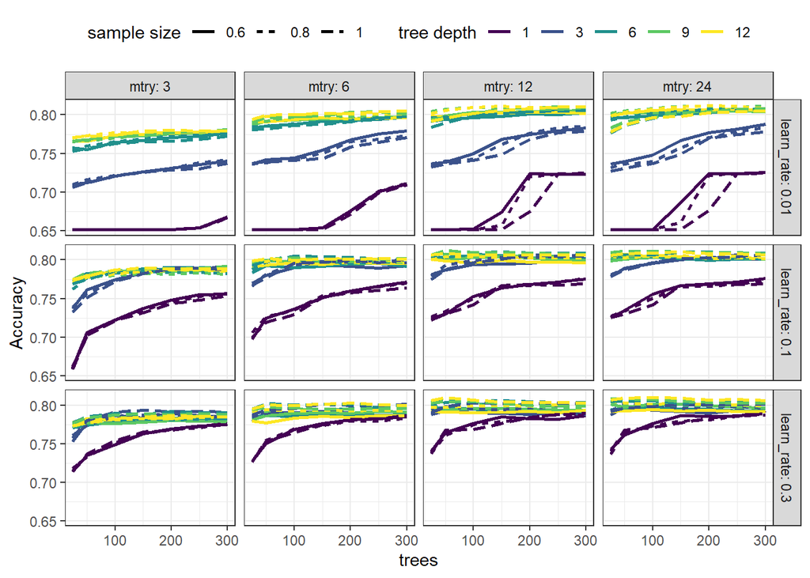

```r
xgb_res_exp %>% collect_metrics() %>%
  filter(.metric == 'accuracy') %>%
  ggplot(mapping = aes(x = trees, y = mean)) +
  geom_line(mapping = aes(color = as.factor(tree_depth),
                          group = interaction(mtry, tree_depth,
                                              learn_rate, sample_size),
                          linetype = as.factor(sample_size)),
            size = 1.) +
  facet_grid(learn_rate ~ mtry, labeller = "label_both") +
  scale_color_viridis_d("tree depth") +
  scale_linetype_discrete("sample size") +
  labs(y = 'Accuracy') +
  theme_bw() +
  theme(legend.position = "top")
```

**The roc_auc resampling results**

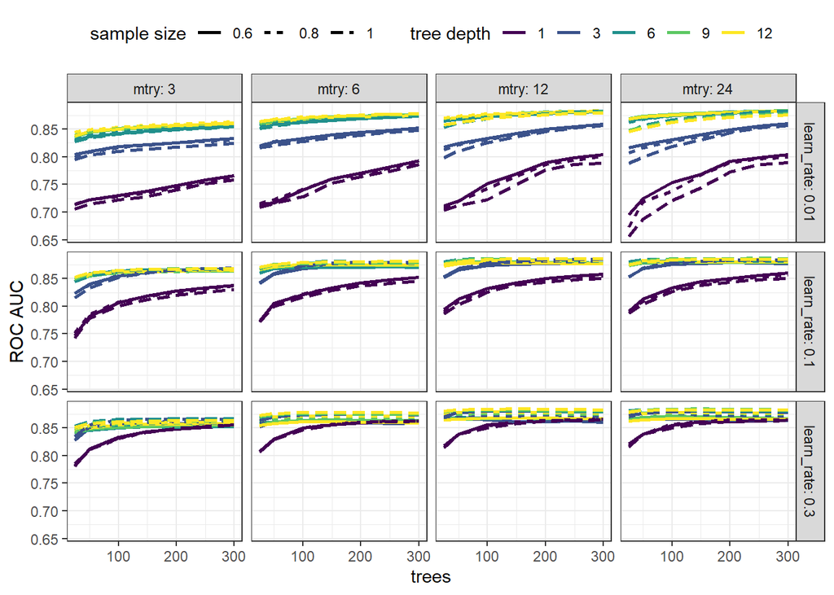

```r
xgb_res_exp %>% collect_metrics() %>%
  filter(.metric == 'roc_auc') %>%
  ggplot(mapping = aes(x = trees, y = mean)) +
  geom_line(mapping = aes(color = as.factor(tree_depth),
                          group = interaction(mtry, tree_depth,
                                              learn_rate, sample_size),
                          linetype = as.factor(sample_size)),
            size = 1.) +
  facet_grid(learn_rate ~ mtry, labeller = "label_both") +
  scale_color_viridis_d("tree depth") +
  scale_linetype_discrete("sample size") +
  labs(y = 'ROC AUC') +
  theme_bw() +
  theme(legend.position = "top")
```

**The mean log loss resampling results**

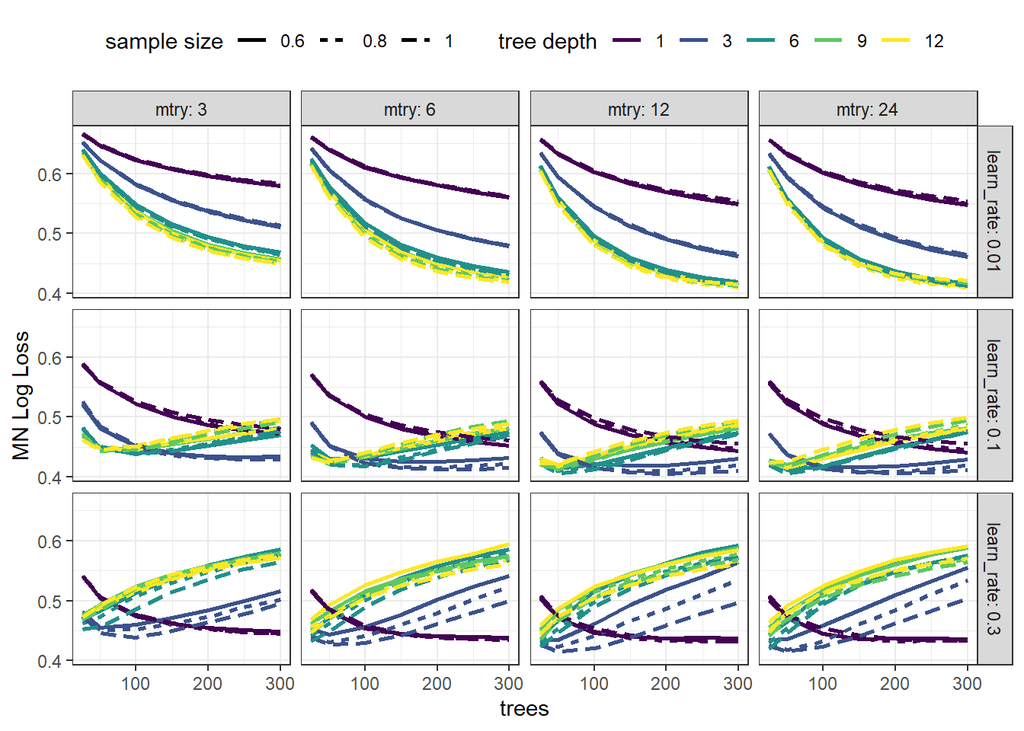

```r
xgb_res_exp %>% collect_metrics() %>%
  filter(.metric == 'mn_log_loss') %>%
  ggplot(mapping = aes(x = trees, y = mean)) +
  geom_line(mapping = aes(color = as.factor(tree_depth),
                          group = interaction(mtry, tree_depth,
                                              learn_rate, sample_size),
                          linetype = as.factor(sample_size)),
            size = 1.) +
  facet_grid(learn_rate ~ mtry, labeller = "label_both") +
  scale_color_viridis_d("tree depth") +
  scale_linetype_discrete("sample size") +
  labs(y = 'MN Log Loss') +
  theme_bw() +
  theme(legend.position = "top")
```

```r
xgb_best_roc_params_exp <- xgb_res_exp %>% select_best('roc_auc')

final_xgb_wflow_exp <- xgb_wflow_exp %>%
  finalize_workflow(xgb_best_roc_params_exp)
```

```r
set.seed(7899)
final_xgb_res_exp <- final_xgb_wflow_exp %>%
  fit_resamples(cv_folds_2,
                metrics = my_metrics,
                control = control_resamples(save_pred = TRUE))
```

```r
set.seed(7899)
final_xgb_fit_exp <- final_xgb_wflow_exp %>% fit(df_derived_cat)
```

```r
all_results <- all_results %>%
  bind_rows(final_xgb_res_exp %>% collect_metrics() %>%
              mutate(wflow_id = "xgb_exp"))
```

### Naive Bayes

```r
library(discrim)
nb_grid <- crossing(smoothness = c(0.5, 0.75, 1.0, 1.25, 1.5),
                    Laplace = c(0, 1, 2, 3))
```

```r
nb_spec <- naive_Bayes(smoothness = tune(), Laplace = tune()) %>%
  set_engine("klaR") %>%
  set_mode("classification")
```

**Using Base Features Set**

```r
nb_wflow_base <- workflow() %>%
  add_model(nb_spec) %>%
  add_recipe(bp_stan_base)
```

```r
start_nb <- Sys.time()

nb_res_base <- tune_grid(
  nb_wflow_base,
  resamples = cv_folds_1,
  grid = nb_grid,
  metrics = my_metrics
)

finish_nb <- Sys.time()

finish_nb - start_nb
```

```
## Time difference of 2.020384 mins
```

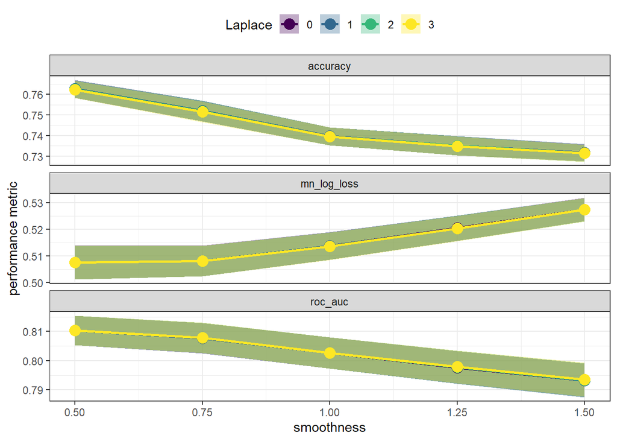

```r
nb_res_base %>% collect_metrics() %>%
  ggplot(mapping = aes(x = smoothness)) +
  geom_ribbon(mapping = aes(ymin = mean - 1 * std_err,
                            ymax = mean + 1 * std_err,
                            group = interaction(Laplace, .metric),
                            fill = as.factor(Laplace)),
              alpha = 0.33) +
  geom_line(mapping = aes(y = mean,
                          color = as.factor(Laplace),
                          group = interaction(Laplace, .metric)),
            size = 1.) +
  geom_point(mapping = aes(y = mean,
                           color = as.factor(Laplace)),
             size = 4) +
  facet_wrap( ~ .metric, scales = "free_y", ncol = 1) +
  scale_fill_viridis_d("Laplace") +
  scale_color_viridis_d("Laplace") +
  labs(y = 'performance metric') +
  theme_bw() +
  theme(legend.position = "top")
```

```r
nb_best_roc_auc_params_base <- nb_res_base %>%
  select_best("roc_auc")

final_nb_wflow_base <- nb_wflow_base %>%
  finalize_workflow(nb_best_roc_auc_params_base)
```

```r
final_nb_res_base <- final_nb_wflow_base %>%
  fit_resamples(cv_folds_1,
                metrics = my_metrics,
                control = control_resamples(save_pred = TRUE))
```

```r
all_results <- all_results %>%
  bind_rows(final_nb_res_base %>% collect_metrics() %>%
              mutate(wflow_id = "nb_base"))
```

**Using Expanded Features Set**

```r
nb_wflow_exp <- workflow() %>%
  add_model(nb_spec) %>%
  add_recipe(bp_stan_exp)
```

```r
start_nb <- Sys.time()

nb_res_exp <- tune_grid(
  nb_wflow_exp,
  resamples = cv_folds_2,
  grid = nb_grid,
  metrics = my_metrics
)

finish_nb <- Sys.time()

finish_nb - start_nb
```

```
## Time difference of 1.966414 mins
```

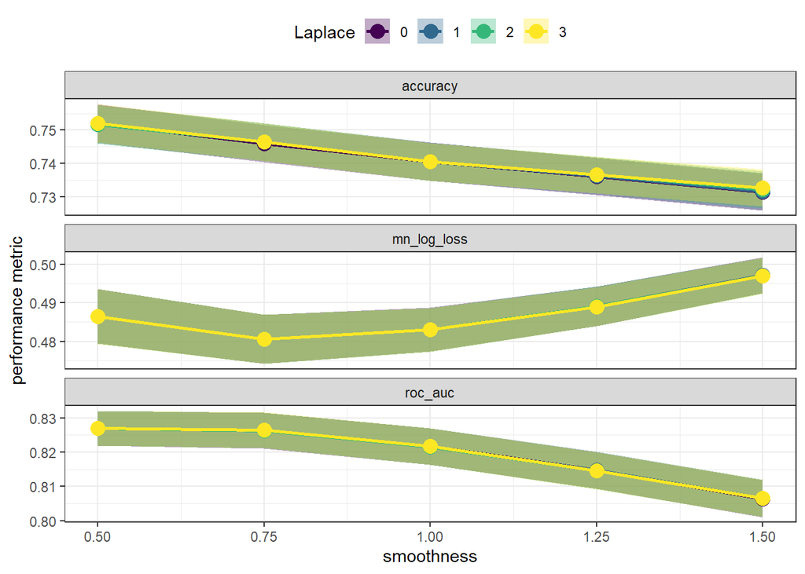

```r
nb_res_exp %>% collect_metrics() %>%
  ggplot(mapping = aes(x = smoothness)) +
  geom_ribbon(mapping = aes(ymin = mean - 1 * std_err,
                            ymax = mean + 1 * std_err,
                            group = interaction(Laplace, .metric),
                            fill = as.factor(Laplace)),
              alpha = 0.33) +
  geom_line(mapping = aes(y = mean,
                          color = as.factor(Laplace),
                          group = interaction(Laplace, .metric)),
            size = 1.) +
  geom_point(mapping = aes(y = mean,
                           color = as.factor(Laplace)),
             size = 4) +
  facet_wrap( ~ .metric, scales = "free_y", ncol = 1) +
  scale_fill_viridis_d("Laplace") +
  scale_color_viridis_d("Laplace") +
  labs(y = 'performance metric') +
  theme_bw() +
  theme(legend.position = "top")
```

```r
nb_best_roc_auc_params_exp <- nb_res_exp %>%
  select_best("roc_auc")

final_nb_wflow_exp <- nb_wflow_exp %>%
  finalize_workflow(nb_best_roc_auc_params_exp)
```

```r
final_nb_res_exp <- final_nb_wflow_exp %>%
  fit_resamples(cv_folds_2,
                metrics = my_metrics,
                control = control_resamples(save_pred = TRUE))
```

```r
all_results <- all_results %>%
  bind_rows(final_nb_res_exp %>% collect_metrics() %>%
              mutate(wflow_id = "nb_exp"))
```

### Support Vector Machine (SVM)

```r
rbf_default <- svm_rbf(cost = 1) %>%
  set_engine('kernlab') %>%
  set_mode('classification')

rbf_default_wflow <- workflow() %>%
  add_model(rbf_default) %>%
  add_recipe(bp_stan_exp)

rbf_default_fit <- rbf_default_wflow %>% fit(df_derived_cat)

rbf_default_fit
```

```
## ══ Workflow [trained] ══════════════════════════════════════════════════════════
## Preprocessor: Recipe
## Model: svm_rbf()
##
## ── Preprocessor ────────────────────────────────────────────────────────────────
## 2 Recipe Steps
##
## • step_center()
## • step_scale()
##
## ── Model ───────────────────────────────────────────────────────────────────────
## Support Vector Machine object of class "ksvm"
##
## SV type: C-svc  (classification)
##  parameter : cost C = 1
##
## Gaussian Radial Basis kernel function.
##  Hyperparameter : sigma =  0.0698960034159159
##
## Number of Support Vectors : 869
##
## Objective Function Value : -751.8859
## Training error : 0.257188
## Probability model included.
```

```r
rbf_grid <- crossing(rbf_sigma = c(0.005, 0.01, 0.025, 0.05, 0.1, 0.25, 0.5),
                     cost = c(0.01, 0.1, 1, 10, 100, 1000))
```

```r
svm_rbf_spec <- svm_rbf(cost = tune(), rbf_sigma = tune()) %>%
  set_engine('kernlab') %>%
  set_mode('classification')
```

```r
svm_rbf_wflow_base <- workflow() %>%
  add_model(svm_rbf_spec) %>%
  add_recipe(bp_stan_base)
```

```r
start_rbf <- Sys.time()

set.seed(7899)
svm_rbf_res_base <- tune_grid(
  svm_rbf_wflow_base,
  resamples = cv_folds_1,
  grid = rbf_grid,
  metrics = my_metrics
)

finish_rbf <- Sys.time()

finish_rbf - start_rbf
```

```r
svm_rbf_res_base %>% readr::write_rds("svm_classi_base.rds")
```

```r
svm_rbf_res_base <- readr::read_rds("svm_classi_base.rds")
```

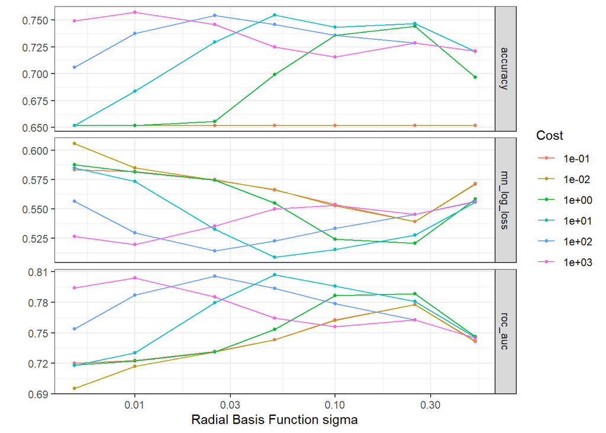

```r
svm_rbf_res_base %>% autoplot() + theme_bw()
```

```r
rbf_best_max_acc_params_base <- svm_rbf_res_base %>%
  select_best(metric = 'accuracy')

final_svm_rbf_wflow_base <- svm_rbf_wflow_base %>%
  finalize_workflow(rbf_best_max_acc_params_base)
```

```r
final_svm_rbf_res_base <- final_svm_rbf_wflow_base %>%
  fit_resamples(cv_folds_1,
                metrics = my_metrics,
                control = control_resamples(save_pred = TRUE))
```

```r
all_results <- all_results %>%
  bind_rows(final_svm_rbf_res_base %>% collect_metrics() %>%
              mutate(wflow_id = "svm_base"))
```

**Using Expanded Features Set**

```r
svm_rbf_wflow_exp <- workflow() %>%
  add_model(svm_rbf_spec) %>%
  add_recipe(bp_stan_exp)
```

```r
start_rbf <- Sys.time()

set.seed(7899)
svm_rbf_res_exp <- tune_grid(
  svm_rbf_wflow_exp,
  resamples = cv_folds_2,
  grid = rbf_grid,
  metrics = my_metrics
)

finish_rbf <- Sys.time()

finish_rbf - start_rbf
```

```r
svm_rbf_res_exp %>% readr::write_rds("svm_classi_exp.rds")
```

```r
svm_rbf_res_exp <- readr::read_rds("svm_classi_exp.rds")
```

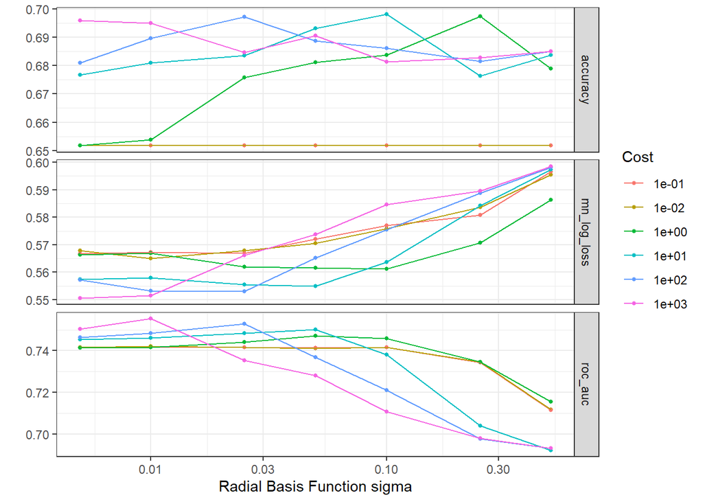

```r
svm_rbf_res_exp %>% autoplot() + theme_bw()
```

```r
rbf_best_max_acc_params_exp <- svm_rbf_res_exp %>%
  select_best(metric = 'accuracy')

final_svm_rbf_wflow_exp <- svm_rbf_wflow_exp %>%
  finalize_workflow(rbf_best_max_acc_params_exp)
```

```r
final_svm_rbf_res_exp <- final_svm_rbf_wflow_exp %>%
  fit_resamples(cv_folds_2,
                metrics = my_metrics,
                control = control_resamples(save_pred = TRUE))
```

```r
all_results <- all_results %>%
  bind_rows(final_svm_rbf_res_exp %>% collect_metrics() %>%
              mutate(wflow_id = "svm_exp"))
```

### Model Comparision

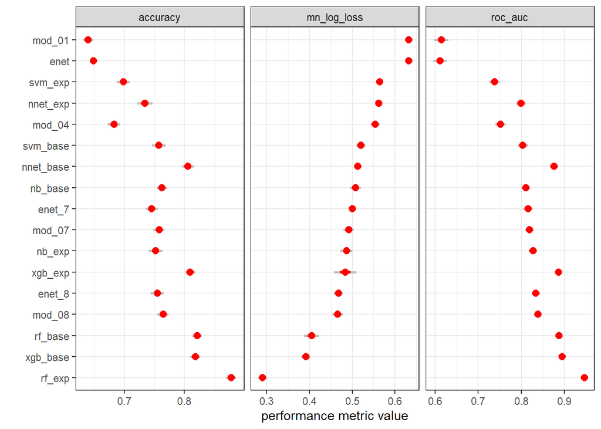

```r
all_results %>%
  mutate(wflow_id = forcats::fct_reorder(wflow_id, mean, min)) %>%
  ggplot(mapping = aes(x = wflow_id)) +
  geom_linerange(mapping = aes(ymin = mean - 2*std_err,
                               ymax = mean + 2*std_err,
                               group = interaction(.metric, wflow_id)),
                 color = 'grey', size = 1.) +
  geom_linerange(mapping = aes(ymin = mean - 1*std_err,
                               ymax = mean + 1*std_err,
                               group = interaction(.metric, wflow_id)),
                 color = 'red', size = 1.2) +
  geom_point(mapping = aes(y = mean),
             color = 'red', size = 2.5) +
  coord_flip() +
  facet_wrap(~.metric, scales = "free_x") +
  labs(y = "performance metric value", x ="") +
  theme_bw()
```

**Our best model is RF model with expanded features when we are maximizing both Accuracy and ROC_AUC**

**Plotting the ROC_AUC curve**

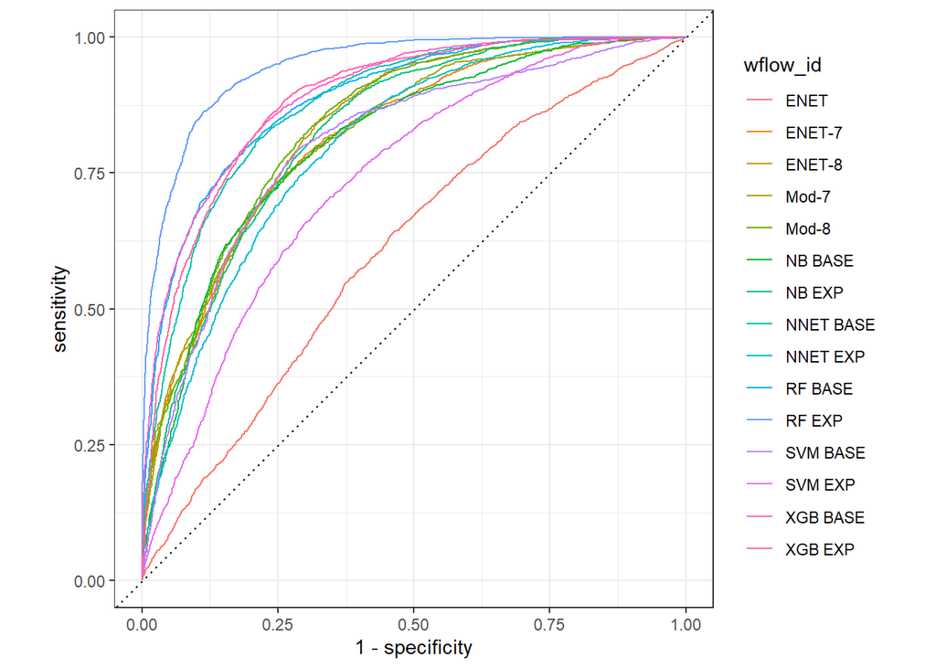

```r
map2_dfr(list(glm_mod7, glm_mod8,
              final_enet_res, final_glm7_enet_res, final_glm8_enet_res,
              final_nnet_base_res, final_nnet_exp_res,
              final_rf_base_res, final_rf_exp_res,
              final_xgb_res_base, final_xgb_res_exp,
              final_nb_res_base, final_nb_res_exp,
              final_svm_rbf_res_base, final_svm_rbf_res_exp),
         c("Mod-7", "Mod-8",
           "ENET", "ENET-7", "ENET-8",
           "NNET BASE", "NNET EXP",
           "RF BASE", "RF EXP",
           "XGB BASE", "XGB EXP",
           "NB BASE", "NB EXP",
           "SVM BASE", "SVM EXP"),
         function(ll, ln){
           ll %>% collect_predictions() %>% mutate(wflow_id = ln)
         }) %>%
  group_by(wflow_id) %>%
  roc_curve(outcome, .pred_event) %>%
  autoplot()
```

```r
all_resample_results <- glm_mod7 %>% collect_metrics(summarize = FALSE) %>%
  mutate(wflow_id = "Mod-7" ) %>%
  bind_rows(glm_mod8 %>% collect_metrics(summarize = FALSE) %>%
              mutate(wflow_id = "Mod-8")) %>%
  bind_rows(final_enet_res %>% collect_metrics(summarize = FALSE) %>%
              mutate(wflow_id = "ENET")) %>%
  bind_rows(final_glm7_enet_res %>% collect_metrics(summarize = FALSE) %>%
              mutate(wflow_id = "ENET-7")) %>%
  bind_rows(final_glm8_enet_res %>% collect_metrics(summarize = FALSE) %>%
              mutate(wflow_id = "ENET-8")) %>%
  bind_rows(final_nnet_base_res %>% collect_metrics(summarize = FALSE) %>%
              mutate(wflow_id = "NNET BASE")) %>%
  bind_rows(final_nnet_exp_res %>% collect_metrics(summarize = FALSE) %>%
              mutate(wflow_id = "NNET EXP")) %>%
  bind_rows(final_rf_base_res %>% collect_metrics(summarize = FALSE) %>%
              mutate(wflow_id = "RF BASE")) %>%
  bind_rows(final_rf_exp_res %>% collect_metrics(summarize = FALSE) %>%
              mutate(wflow_id = "RF EXP")) %>%
  bind_rows(final_xgb_res_base %>% collect_metrics(summarize = FALSE) %>%
              mutate(wflow_id = "XGB BASE")) %>%
  bind_rows(final_xgb_res_exp %>% collect_metrics(summarize = FALSE) %>%
              mutate(wflow_id = "XGB EXP")) %>%
  bind_rows(final_nb_res_base %>% collect_metrics(summarize = FALSE) %>%
              mutate(wflow_id = "NB BASE")) %>%
  bind_rows(final_nb_res_exp %>% collect_metrics(summarize = FALSE) %>%
              mutate(wflow_id = "NB EXP")) %>%
  bind_rows(final_svm_rbf_res_base %>% collect_metrics(summarize = FALSE) %>%
              mutate(wflow_id = "SVM BASE")) %>%
  bind_rows(final_svm_rbf_res_exp %>% collect_metrics(summarize = FALSE) %>%
              mutate(wflow_id = "SVM EXP")) %>%
  mutate(wflow_id = factor(wflow_id,
                           levels = c("Mod-7", "Mod-8",
           "ENET", "ENET-7", "ENET-8",
           "NNET BASE", "NNET EXP",
           "RF BASE", "RF EXP",
           "XGB BASE", "XGB EXP",
           "NB BASE", "NB EXP",
           "SVM BASE", "SVM EXP")))
```

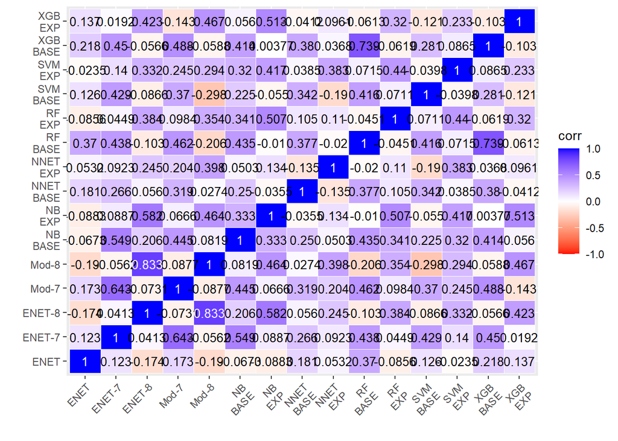

```r
all_resample_results %>%
  mutate(wflow_id = stringr::str_replace(wflow_id, " ", "\n")) %>%
  filter(.metric == 'accuracy') %>%
  select(wflow_id, .estimate, id, id2) %>%
  pivot_wider(id_cols = c("id", "id2"),
              names_from = 'wflow_id', values_from = '.estimate') %>%
  select(-id, -id2) %>%
  corrr::correlate(quiet = TRUE, diagonal = 1) %>%
  corrr::stretch() %>%
  ggplot(mapping = aes(x = x, y = y)) +
  geom_tile(mapping = aes(fill = r),
            color = 'white') +
  geom_text(mapping = aes(label = signif(r, 3),
                          color = abs(r) > 0.75),
            size = 3.5) +
  scale_fill_gradient2('corr',
                       low = 'red', mid = 'white', high = 'blue',
                       midpoint = 0,
                       limits = c(-1, 1)) +
  scale_color_manual(guide = 'none',
                     values = c("TRUE" = 'white',
                                "FALSE" = 'black')) +
  labs(x='', y='') +
  theme(axis.text.x = element_text(angle = 45, vjust = 1, hjust = 1))
```

From the above plot we can see that the results of XGB BASE model and RF BASE model are highly correlated.

# Variable Importance

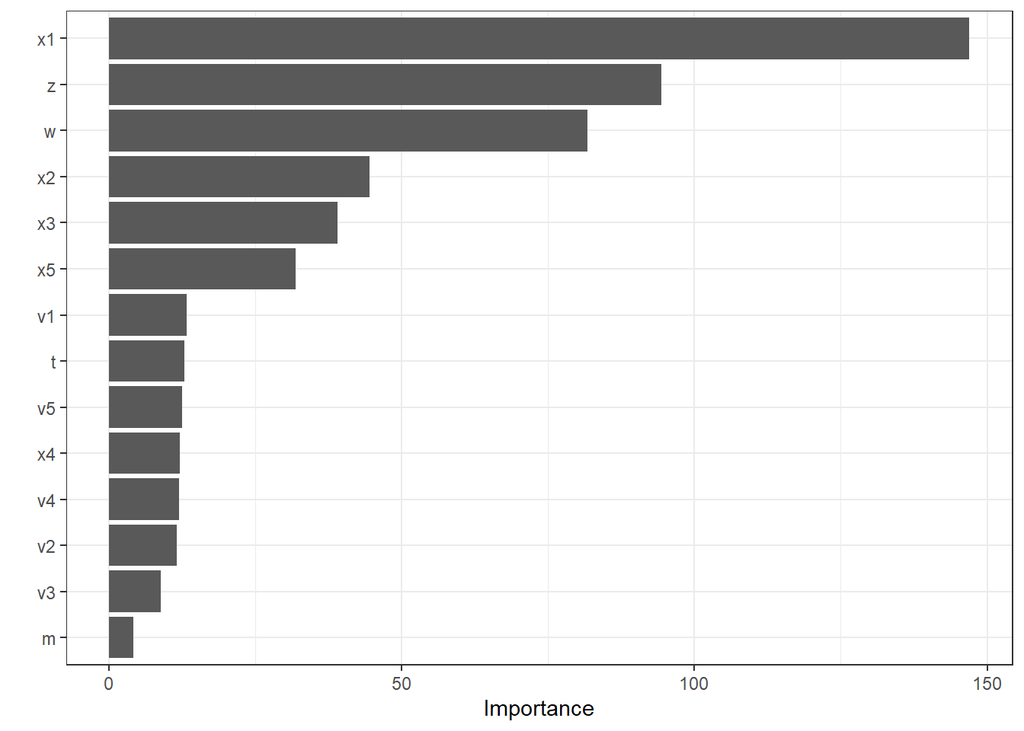

```r
library(vip)
final_rf_exp_fit %>%
  extract_fit_parsnip() %>%
  pluck("fit") %>%
  vip(num_features = 20) +
  theme_bw()
```

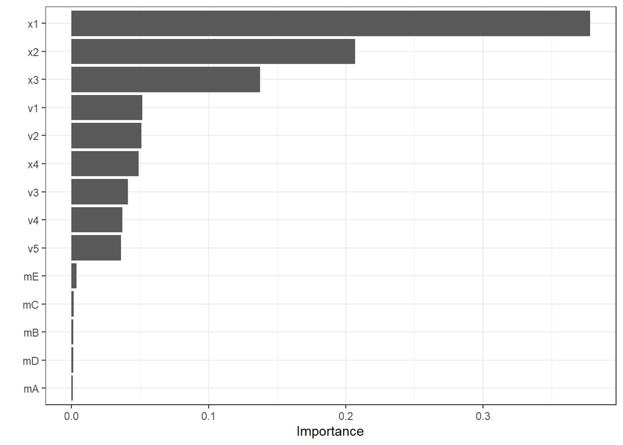

```r
final_xgb_fit_base %>%
  extract_fit_parsnip() %>%
  pluck("fit") %>%
  vip(num_features = 20) +
  theme_bw()
```

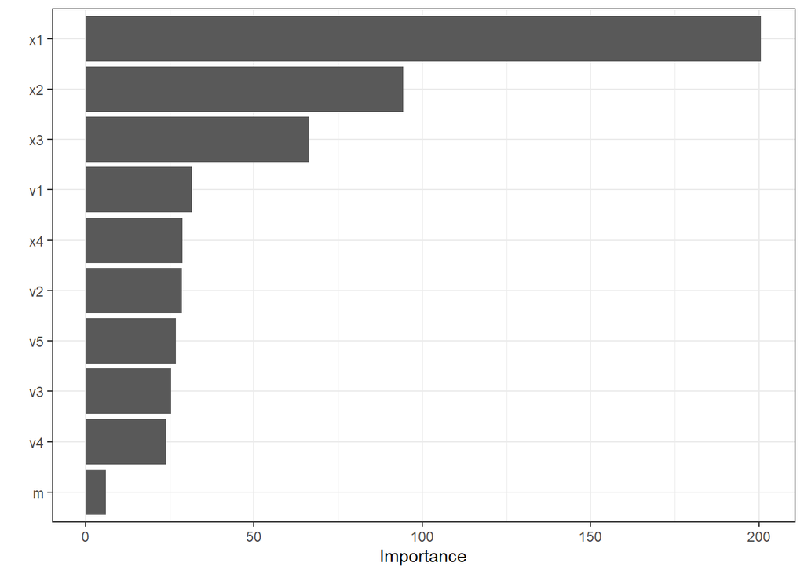

```r
final_rf_base_fit %>%
  extract_fit_parsnip() %>%
  pluck("fit") %>%
  vip(num_features = 20) +
  theme_bw()
```

Both the random forest and gradient boosted trees are giving **x1, x2, x3** as most imporatnt features.  
But when we are using the expanded features set we get **x1** as the most important feature but we get **z** and **w** as the second and the third most important features.